# CLASIFICACION

CARLOS ALEX NINA GUARDAPUCLLA

2023-01-07

**Análisis comparativo de las técnicas de clasificación**

**Tabla de contenido**

1. IMPORTACIÓN DE BIBLIOTECAS
2. CARGA DE DATOS
3. LIMPIEZA DE DATOS
4. PREPROCESAMIENTO DE DATOS
5. ESCALAR DATOS.
6. ANÁLISIS DE COMPONENTES PRINCIPALES (PCA)
7. PARTICIONAR EN DATOS DE ENTRENAMIENTO Y PRUEBA.
8. CREAR MODELOS DE CLASIFICACION.
- ctree
- C45
- SVM
- KNN
- rules
- randomForest
- xgboost
- NeuralNet
9. Evaluacion de los modelos
10. Pruebas y matriz de confusion.
11. Conclusion
12. Extra: otras formas de crear los modelos de clasificacion con otras librerias

**1. - IMPORTACION DE BIBLIOTECAS**

```r
library(tidyverse)
library(caret)
```

```r
library(ggcorrplot)
library(lattice)
library(RWeka)
library(party)
library(dplyr)
library(plotly)
library(ggplot2)
library(reshape2)
library(ggthemes)
library(DataExplorer)
library(psych)
library(ggcorrplot)
library(FactoMineR)
library(factoextra)
```

**2. - CARGA DE DATOS**

*Cargando el conjunto de datos*

```r
dataset_cancer<-read.table(file="datos/breast-cancer-wisconsin.data", header = TRUE, sep = ",")
```

*Mostrar contenido del dataset*

```r
# MOSTRAR LAS PRIMERAS FILAS
dataset_cancer <- as_tibble(dataset_cancer)
head(dataset_cancer)
```

```
## # A tibble: 6 × 11
##   X1000025    X5    X1  X1.1  X1.2    X2 X1.3     X3  X1.4  X1.5  X2.1
##      <int> <int> <int> <int> <int> <int> <chr> <int> <int> <int> <int>
## 1  1002945     5     4     4     5     7 10        3     2     1     2
## 2  1015425     3     1     1     1     2 2         3     1     1     2
## 3  1016277     6     8     8     1     3 4         3     7     1     2
## 4  1017023     4     1     1     3     2 1         3     1     1     2
## 5  1017122     8    10    10     8     7 10        9     7     1     4
## 6  1018099     1     1     1     1     2 10        3     1     1     2
```

```r
# MOSTRAR LAS ULTIMAS FILAS
tail(dataset_cancer)
```

```
## # A tibble: 6 × 11
##   X1000025    X5    X1  X1.1  X1.2    X2 X1.3     X3  X1.4  X1.5  X2.1
##      <int> <int> <int> <int> <int> <int> <chr> <int> <int> <int> <int>
## 1   763235     3     1     1     1     2 1         2     1     2     2
## 2   776715     3     1     1     1     3 2         1     1     1     2
## 3   841769     2     1     1     1     2 1         1     1     1     2
## 4   888820     5    10    10     3     7 3         8    10     2     4
## 5   897471     4     8     6     4     3 4        10     6     1     4
## 6   897471     4     8     8     5     4 5        10     4     1     4
```

*-La primera columna corresponde al ID el cual no aporta informacion relevante para los posteriores procesos a realizar*

**3. - LIMPIEZA DE DATOS**

*Eliminando contenido poco relevante*

```r
# Eliminando columna con id's
dataset_temp <- dataset_cancer[,-c(1)]
head(dataset_temp)
```

```
## # A tibble: 6 × 10
##      X5    X1  X1.1  X1.2    X2 X1.3     X3  X1.4  X1.5  X2.1
##   <int> <int> <int> <int> <int> <chr> <int> <int> <int> <int>
## 1     5     4     4     5     7 10        3     2     1     2
## 2     3     1     1     1     2 2         3     1     1     2
## 3     6     8     8     1     3 4         3     7     1     2
## 4     4     1     1     3     2 1         3     1     1     2
## 5     8    10    10     8     7 10        9     7     1     4
## 6     1     1     1     1     2 10        3     1     1     2
```

*- Se observa que las columnas no tienen un nombre adecuado, por lo tanto se debe proceder a renombrarlas*

**4. - PREPROCESAMIENTO DE DATOS**

*Renombrando las columnas*

```r
dataset_cancer <- dataset_temp
names(dataset_cancer) <- c("Espesor_grupo_celulas", "Uniformiformidad_tamanio_celular", "Uniformiformidad_forma_celular",   "Adhesion_marginal","Tamanio_celula_epitelial","Nucleos_desnudos", "Cromatina_blanda","Nucleolos_normales","Mitosis","Clases")
rownames(dataset_cancer) <- NULL # resetear los indices
head(dataset_cancer)
```

```
## # A tibble: 6 × 10
##   Espes…¹ Unifo…² Unifo…³ Adhes…⁴ Taman…⁵ Nucle…⁶ Croma…⁷ Nucle…⁸ Mitosis Clases
##     <int>   <int>   <int>   <int>   <int> <chr>     <int>   <int>   <int>  <int>
## 1       5       4       4       5       7 10            3       2       1      2
## 2       3       1       1       1       2 2             3       1       1      2
## 3       6       8       8       1       3 4             3       7       1      2
## 4       4       1       1       3       2 1             3       1       1      2
## 5       8      10      10       8       7 10            9       7       1      4
## 6       1       1       1       1       2 10            3       1       1      2
## # … with abbreviated variable names ¹Espesor_grupo_celulas,
## #   ²Uniformiformidad_tamanio_celular, ³Uniformiformidad_forma_celular,
## #   ⁴Adhesion_marginal, ⁵Tamanio_celula_epitelial, ⁶Nucleos_desnudos,
## #   ⁷Cromatina_blanda, ⁸Nucleolos_normales
```

*Identificacion y tratamiento de datos nulos*

```r
# Verificar si existen datos nulos
colSums(is.na(dataset_cancer))
```

```
##            Espesor_grupo_celulas Uniformiformidad_tamanio_celular
##                                0                                0
##   Uniformiformidad_forma_celular                Adhesion_marginal
##                                0                                0
##         Tamanio_celula_epitelial                 Nucleos_desnudos
##                                0                                0
##                 Cromatina_blanda               Nucleolos_normales
##                                0                                0
##                          Mitosis                           Clases
##                                0                                0
```

*- Se observa que no hay presencia de datos nulos o faltantes*

```r
# Mostrar descripcion del dataset
str(dataset_cancer)
```

```
## tibble [698 × 10] (S3: tbl_df/tbl/data.frame)
##  $ Espesor_grupo_celulas           : int [1:698] 5 3 6 4 8 1 2 2 4 1 ...
##  $ Uniformiformidad_tamanio_celular: int [1:698] 4 1 8 1 10 1 1 1 2 1 ...
##  $ Uniformiformidad_forma_celular  : int [1:698] 4 1 8 1 10 1 2 1 1 1 ...
##  $ Adhesion_marginal               : int [1:698] 5 1 1 3 8 1 1 1 1 1 ...
##  $ Tamanio_celula_epitelial        : int [1:698] 7 2 3 2 7 2 2 2 2 1 ...
##  $ Nucleos_desnudos                : chr [1:698] "10" "2" "4" "1" ...
##  $ Cromatina_blanda                : int [1:698] 3 3 3 3 9 3 3 1 2 3 ...
##  $ Nucleolos_normales              : int [1:698] 2 1 7 1 7 1 1 1 1 1 ...
##  $ Mitosis                         : int [1:698] 1 1 1 1 1 1 1 5 1 1 ...
##  $ Clases                          : int [1:698] 2 2 2 2 4 2 2 2 2 2 ...
```

```r
# Mostrar resumen estadistico de las columnas
summary(dataset_cancer)
```

```
##  Espesor_grupo_celulas Uniformiformidad_tamanio_celular
##  Min.   : 1.000        Min.   : 1.000
##  1st Qu.: 2.000        1st Qu.: 1.000
##  Median : 4.000        Median : 1.000
##  Mean   : 4.417        Mean   : 3.138
##  3rd Qu.: 6.000        3rd Qu.: 5.000
##  Max.   :10.000        Max.   :10.000
##  Uniformiformidad_forma_celular Adhesion_marginal Tamanio_celula_epitelial
##  Min.   : 1.000                 Min.   : 1.000    Min.   : 1.000
##  1st Qu.: 1.000                 1st Qu.: 1.000    1st Qu.: 2.000
##  Median : 1.000                 Median : 1.000    Median : 2.000
##  Mean   : 3.211                 Mean   : 2.809    Mean   : 3.218
##  3rd Qu.: 5.000                 3rd Qu.: 4.000    3rd Qu.: 4.000
##  Max.   :10.000                 Max.   :10.000    Max.   :10.000
##  Nucleos_desnudos   Cromatina_blanda Nucleolos_normales    Mitosis
##  Length:698         Min.   : 1.000   Min.   : 1.00      Min.   : 1.00
##  Class :character   1st Qu.: 2.000   1st Qu.: 1.00      1st Qu.: 1.00
##  Mode  :character   Median : 3.000   Median : 1.00      Median : 1.00
##                     Mean   : 3.438   Mean   : 2.87      Mean   : 1.59
##                     3rd Qu.: 5.000   3rd Qu.: 4.00      3rd Qu.: 1.00
##                     Max.   :10.000   Max.   :10.00      Max.   :10.00
##      Clases
##  Min.   :2.000
##  1st Qu.:2.000
##  Median :2.000
##  Mean   :2.691
##  3rd Qu.:4.000
##  Max.   :4.000
```

*Mostrar datos únicos de cada columna*

```r
sapply(dataset_cancer, unique)
```

```
## $Espesor_grupo_celulas
##  [1]  5  3  6  4  8  1  2  7 10  9
##
## $Uniformiformidad_tamanio_celular
##  [1]  4  1  8 10  2  3  7  5  6  9
##
## $Uniformiformidad_forma_celular
##  [1]  4  1  8 10  2  3  5  6  7  9
##
## $Adhesion_marginal
##  [1]  5  1  3  8 10  4  6  2  9  7
##
## $Tamanio_celula_epitelial
##  [1]  7  2  3  1  6  4  5  8 10  9
##
## $Nucleos_desnudos
##  [1] "10" "2"  "4"  "1"  "3"  "9"  "7"  "?"  "5"  "8"  "6"
##
## $Cromatina_blanda
##  [1]  3  9  1  2  4  5  7  8  6 10
##
## $Nucleolos_normales
##  [1]  2  1  7  4  5  3 10  6  9  8
##
## $Mitosis
## [1]  1  5  4  2  3  7 10  8  6
##
## $Clases
## [1] 2 4
```

*- Se observa que la columna “Nucleos_desnudos” es de tipo caracter y posee caracteres que no corresponde con la mayoria de datos*

*Reemplazar “?” de la columna “Nucleos_desnudos” por la moda de la misma*

```r
# Obtener la moda de dicha columna
mode <- function(x) {
   return(as.numeric(names(which.max(table(x)))))
}
moda_Nucleos_desnudos = mode(dataset_cancer$Nucleos_desnudos)
moda_Nucleos_desnudos
```

```
## [1] 1
```

```r
# Tratamiento de caracter extraño
dataset_cancer$Nucleos_desnudos[dataset_cancer$Nucleos_desnudos=="?"] <- moda_Nucleos_desnudos

# corregir el tipo de dato de dicha columna "Nucleos_desnudos"
dataset_cancer$Nucleos_desnudos<- as.integer(dataset_cancer$Nucleos_desnudos)

# corregir el tipo de dato de la columna "clase"
dataset_cancer$Clases<- as.factor(dataset_cancer$Clases)
```

```r
unique(dataset_cancer$Nucleos_desnudos)
```

```
##  [1] 10  2  4  1  3  9  7  5  8  6
```

*- Se observa que dicho caracter fue eliminado y el tipo de dato fue corregido*

*Visualizando la distribucion de los datos mediante el histograma*

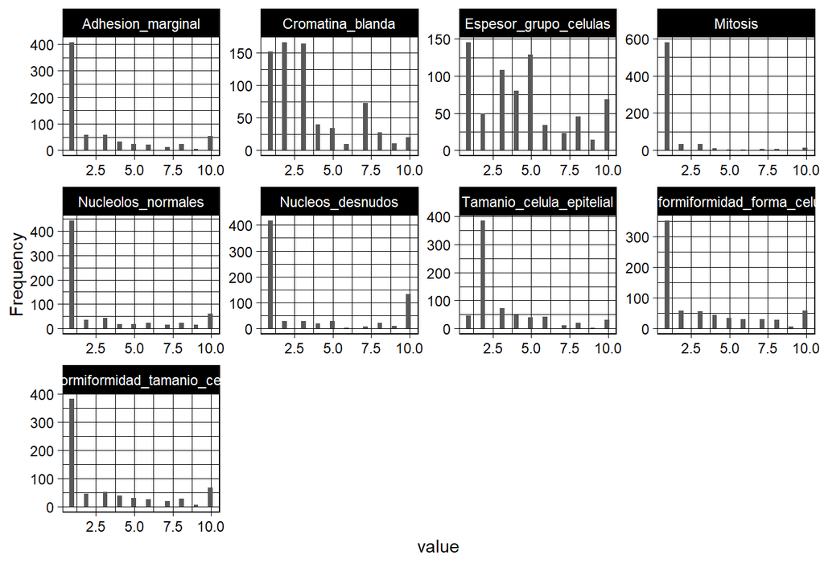

```r
plot_histogram(dataset_cancer,ggtheme = theme_linedraw())
```

**5.- ESCALAR LOS DATOS**

*- Se procede a normalizar los datos para trabajar en una misma escala*

```r
# Crear una copia del dataset limpio
dataset_scale <- dataset_cancer
```

```r
# Escalar las columnas numéricas
dataset_scale <- dataset_scale[,1:9]
dataset_scale <- scale(dataset_scale)
dataset_scale <- data.frame(dataset_scale)
# Agregando nuevamente la columna "Clases" al dataset escalado
dataset_scale <- mutate(dataset_scale, Clases = dataset_cancer$Clases)
summary(dataset_scale)
```

```
##  Espesor_grupo_celulas Uniformiformidad_tamanio_celular
##  Min.   :-1.2127       Min.   :-0.7002
##  1st Qu.:-0.8578       1st Qu.:-0.7002
##  Median :-0.1480       Median :-0.7002
##  Mean   : 0.0000       Mean   : 0.0000
##  3rd Qu.: 0.5618       3rd Qu.: 0.6101
##  Max.   : 1.9815       Max.   : 2.2481
##  Uniformiformidad_forma_celular Adhesion_marginal Tamanio_celula_epitelial
##  Min.   :-0.7436                Min.   :-0.6334   Min.   :-1.0011
##  1st Qu.:-0.7436                1st Qu.:-0.6334   1st Qu.:-0.5497
##  Median :-0.7436                Median :-0.6334   Median :-0.5497
##  Mean   : 0.0000                Mean   : 0.0000   Mean   : 0.0000
##  3rd Qu.: 0.6019                3rd Qu.: 0.4168   3rd Qu.: 0.3531
##  Max.   : 2.2838                Max.   : 2.5172   Max.   : 3.0614
##  Nucleos_desnudos  Cromatina_blanda  Nucleolos_normales    Mitosis
##  Min.   :-0.6872   Min.   :-0.9993   Min.   :-0.612     Min.   :-0.3439
##  1st Qu.:-0.6872   1st Qu.:-0.5895   1st Qu.:-0.612     1st Qu.:-0.3439
##  Median :-0.6872   Median :-0.1797   Median :-0.612     Median :-0.3439
##  Mean   : 0.0000   Mean   : 0.0000   Mean   : 0.000     Mean   : 0.0000
##  3rd Qu.: 0.4168   3rd Qu.: 0.6400   3rd Qu.: 0.370     3rd Qu.:-0.3439
##  Max.   : 1.7967   Max.   : 2.6891   Max.   : 2.334     Max.   : 4.9003
##  Clases
##  2:457
##  4:241
##
##
##
##
```

*Análisis de correlacion*

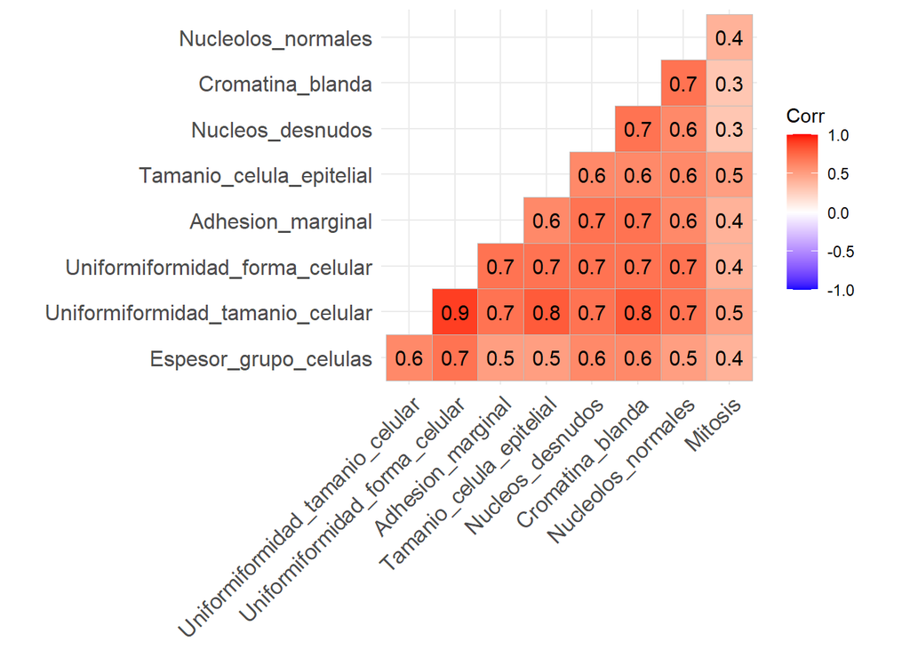

```r
ggcorrplot(round(cor(dataset_scale[,1:9]), 1), type = "lower", lab = T, show.legend = T,tl.srt=45)
```

*- Todas las variables presentan una correlacion positiva”*

*- Mitosis es una variable que presenta baja correlacion respecto a las demas variables”*

*- Se observa una correlacion positiva alta entre las variables “Uniformidad_forma_celular” y “Uniformidad_tamanio_celular”*

**6.- ANÁLISIS DE COMPONENTES PRINCIPALES (PCA)**

```r
dataset_scale_PCA.pca <- PCA(dataset_scale[,1:9], graph=FALSE)
print(dataset_scale_PCA.pca)
```

```
## **Results for the Principal Component Analysis (PCA)**
## The analysis was performed on 698 individuals, described by 9 variables
## *The results are available in the following objects:
##
##    name               description
## 1  "$eig"             "eigenvalues"
## 2  "$var"             "results for the variables"
## 3  "$var$coord"       "coord. for the variables"
## 4  "$var$cor"         "correlations variables - dimensions"
## 5  "$var$cos2"        "cos2 for the variables"
## 6  "$var$contrib"     "contributions of the variables"
## 7  "$ind"             "results for the individuals"
## 8  "$ind$coord"       "coord. for the individuals"
## 9  "$ind$cos2"        "cos2 for the individuals"
## 10 "$ind$contrib"     "contributions of the individuals"
## 11 "$call"            "summary statistics"
## 12 "$call$centre"     "mean of the variables"
## 13 "$call$ecart.type" "standard error of the variables"
## 14 "$call$row.w"      "weights for the individuals"
## 15 "$call$col.w"      "weights for the variables"
```

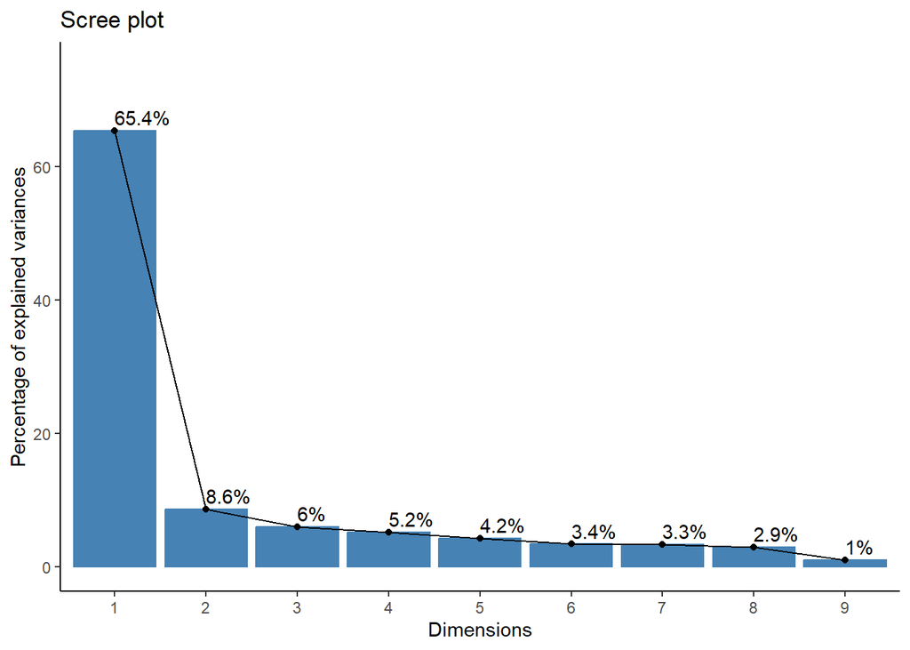

```r
fviz_screeplot(dataset_scale_PCA.pca, addlabels = TRUE, ylim = c(0, 75)) +
  theme_classic()
```

*Se observa que las 2 primeras dimenciones retienen aproximadamente el 74% de las varianzas contenidas en el conjunto de datos.*

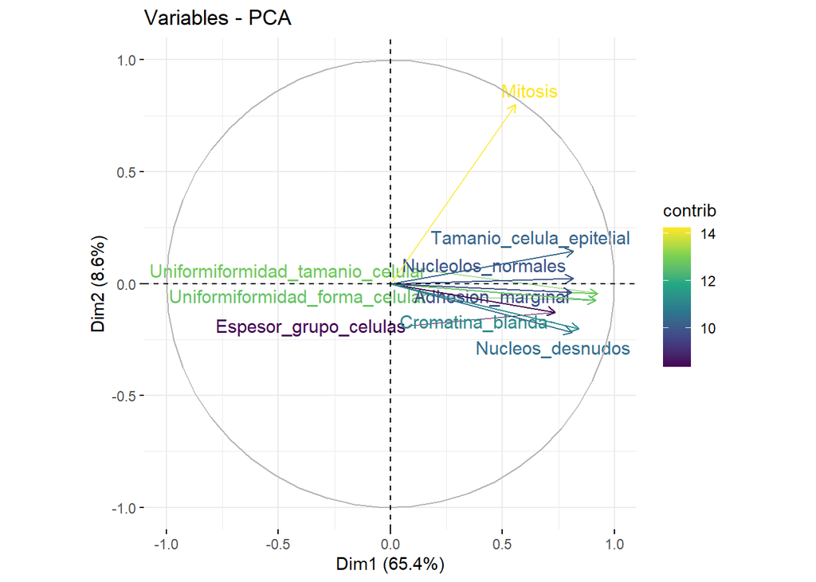

```r
fviz_pca_var(dataset_scale_PCA.pca, col.var="contrib",
             repel = TRUE
             )+scale_colour_viridis_c()
```

*Segun el grafico se observa que la variable “Mitosis” presenta casi una ortogonalidad respecto a algunas variables*

**6.- Clasificación: Técnicas Alternativas**

*Datos de entrenamiento y prueba*

```r
dataset_scale <- data.frame(dataset_scale)
inTrain <- createDataPartition(y = dataset_scale$Clases, p = .8, list = FALSE)
cancer_train <- dataset_scale %>% slice(inTrain)
cancer_test <- dataset_scale %>% slice(-inTrain)
```

- Crear un esquema de muestreo fijo (10 folds)

```r
train_index <- createFolds(cancer_train$Clases, k = 10)
```

*Árbol de inferencia condicional (Árbol de decisión)*

```r
library(rpart)
```

```r
tree_decision <- rpart(Clases ~ ., data = cancer_train, method = "class")
```

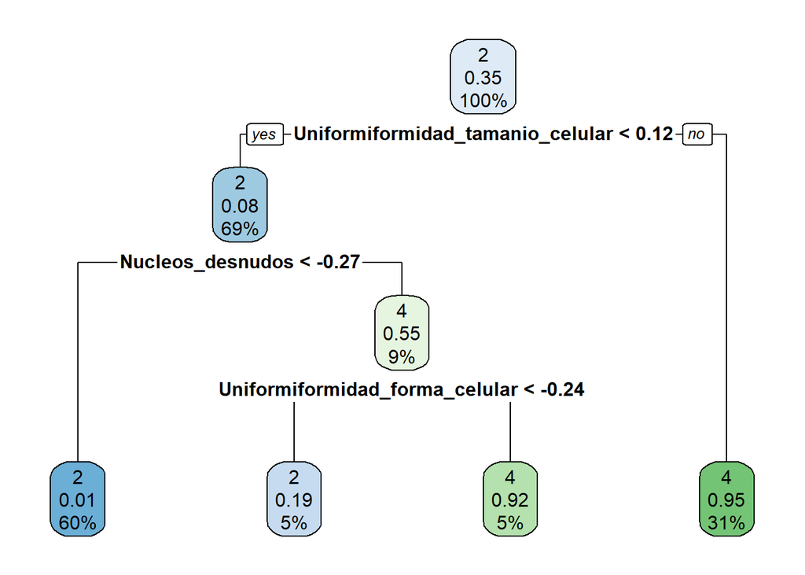

```r
library(rpart.plot)
rpart.plot(tree_decision)
```

```r
# otra forma de crear el arbol de decision

ctreeFit <- cancer_train %>% train(Clases ~ .,
            method = "ctree",
            data = .,
            tuneLength = 5,
            trControl = trainControl(method = "cv", indexOut = train_index))
ctreeFit
```

```
## Conditional Inference Tree
##
## 559 samples
##   9 predictor
##   2 classes: '2', '4'
##
## No pre-processing
## Resampling: Cross-Validated (10 fold)
## Summary of sample sizes: 503, 503, 502, 503, 503, 502, ...
## Resampling results across tuning parameters:
##
##   mincriterion  Accuracy   Kappa
##   0.010         0.9550940  0.9013214
##   0.255         0.9550940  0.9013214
##   0.500         0.9569122  0.9053912
##   0.745         0.9569122  0.9053912
##   0.990         0.9569435  0.9058868
##
## Accuracy was used to select the optimal model using the largest value.
## The final value used for the model was mincriterion = 0.99.
```

[figure not shown]

```r
plot(ctreeFit$finalModel)
```

```r
ctreeFit$finalModel
```

```
##
##   Conditional inference tree with 10 terminal nodes
##
## Response:  .outcome
## Inputs:  Espesor_grupo_celulas, Uniformiformidad_tamanio_celular, Uniformiformidad_forma_celular, Adhesion_marginal, Tamanio_celula_epitelial, Nucleos_desnudos, Cromatina_blanda, Nucleolos_normales, Mitosis
## Number of observations:  559
##
## 1) Uniformiformidad_forma_celular <= -0.07084129; criterion = 1, statistic = 376.862
##   2) Nucleos_desnudos <= 0.416755; criterion = 1, statistic = 214.707
##     3) Uniformiformidad_tamanio_celular <= -0.3726479; criterion = 1, statistic = 124.508
##       4) Nucleos_desnudos <= 0.1407636; criterion = 1, statistic = 47.939
##         5) Cromatina_blanda <= -0.5894927; criterion = 1, statistic = 27.875
##           6)*  weights = 229
##         5) Cromatina_blanda > -0.5894927
##           7) Tamanio_celula_epitelial <= -1.001064; criterion = 1, statistic = 26.295
##             8)*  weights = 7
##           7) Tamanio_celula_epitelial > -1.001064
##             9)*  weights = 85
##       4) Nucleos_desnudos > 0.1407636
##         10)*  weights = 8
##     3) Uniformiformidad_tamanio_celular > -0.3726479
##       11) Espesor_grupo_celulas <= 0.2069419; criterion = 0.995, statistic = 11.759
##         12)*  weights = 21
##       11) Espesor_grupo_celulas > 0.2069419
##         13)*  weights = 8
##   2) Nucleos_desnudos > 0.416755
##     14)*  weights = 18
## 1) Uniformiformidad_forma_celular > -0.07084129
##   15) Uniformiformidad_tamanio_celular <= -0.3726479; criterion = 1, statistic = 29.286
##     16)*  weights = 9
##   15) Uniformiformidad_tamanio_celular > -0.3726479
##     17) Uniformiformidad_tamanio_celular <= 0.2825366; criterion = 0.997, statistic = 12.585
##       18)*  weights = 42
##     17) Uniformiformidad_tamanio_celular > 0.2825366
##       19)*  weights = 132
```

*Además se observa que hay presencia de nodos que presentan alto grado de impureza*

*a) C4.5 Decision Tree*

```r
library(RWeka)
C45Fit <- cancer_train %>% train(Clases ~ .,
            method = "J48",
            data = .,
            tuneLength = 5,
            trControl = trainControl(method = "cv", indexOut = train_index))
C45Fit
```

```
## C4.5-like Trees
##
## 559 samples
##   9 predictor
##   2 classes: '2', '4'
##
## No pre-processing
## Resampling: Cross-Validated (10 fold)
## Summary of sample sizes: 504, 502, 503, 504, 502, 503, ...
## Resampling results across tuning parameters:
##
##   C       M  Accuracy   Kappa
##   0.0100  1  0.9731146  0.9417169
##   0.0100  2  0.9642162  0.9220553
##   0.0100  3  0.9624305  0.9179325
##   0.0100  4  0.9606123  0.9137688
##   0.0100  5  0.9588579  0.9101293
##   0.1325  1  0.9820756  0.9608457
##   0.1325  2  0.9749003  0.9447582
##   0.1325  3  0.9712964  0.9366668
##   0.1325  4  0.9712964  0.9371580
##   0.1325  5  0.9677239  0.9293548
##   0.2550  1  0.9874015  0.9721421
##   0.2550  2  0.9856157  0.9681075
##   0.2550  3  0.9731459  0.9408776
##   0.2550  4  0.9695096  0.9335086
##   0.2550  5  0.9695409  0.9331064
##   0.3775  1  0.9892196  0.9762119
##   0.3775  2  0.9856157  0.9681075
##   0.3775  3  0.9784717  0.9521589
##   0.3775  4  0.9748354  0.9443141
##   0.3775  5  0.9712953  0.9367458
##   0.5000  1  0.9892834  0.9764609
##   0.5000  2  0.9856157  0.9681075
##   0.5000  3  0.9784717  0.9521589
##   0.5000  4  0.9748354  0.9443141
##   0.5000  5  0.9677239  0.9283544
##
## Accuracy was used to select the optimal model using the largest value.
## The final values used for the model were C = 0.5 and M = 1.
```

```r
C45Fit$finalModel
```

```
## J48 pruned tree
## ------------------
##
## Uniformiformidad_tamanio_celular <= -0.372648
## |   Nucleos_desnudos <= -0.411219: 2 (314.0/1.0)
## |   Nucleos_desnudos > -0.411219
## |   |   Uniformiformidad_forma_celular <= -0.407217
## |   |   |   Espesor_grupo_celulas <= 0.916747: 2 (21.0/1.0)
## |   |   |   Espesor_grupo_celulas > 0.916747: 4 (2.0)
## |   |   Uniformiformidad_forma_celular > -0.407217: 4 (7.0)
## Uniformiformidad_tamanio_celular > -0.372648
## |   Uniformiformidad_forma_celular <= -0.407217
## |   |   Espesor_grupo_celulas <= 0.206942: 2 (16.0)
## |   |   Espesor_grupo_celulas > 0.206942: 4 (4.0)
## |   Uniformiformidad_forma_celular > -0.407217
## |   |   Uniformiformidad_tamanio_celular <= 0.282537
## |   |   |   Nucleos_desnudos <= -0.411219
## |   |   |   |   Adhesion_marginal <= 0.066703
## |   |   |   |   |   Nucleolos_normales <= 1.352002
## |   |   |   |   |   |   Cromatina_blanda <= 1.049814: 2 (9.0)
## |   |   |   |   |   |   Cromatina_blanda > 1.049814: 4 (1.0)
## |   |   |   |   |   Nucleolos_normales > 1.352002: 4 (1.0)
## |   |   |   |   Adhesion_marginal > 0.066703: 4 (2.0)
## |   |   |   Nucleos_desnudos > -0.411219
## |   |   |   |   Uniformiformidad_forma_celular <= 0.265534
## |   |   |   |   |   Espesor_grupo_celulas <= 1.626553
## |   |   |   |   |   |   Cromatina_blanda <= 1.049814
## |   |   |   |   |   |   |   Uniformiformidad_forma_celular <= -0.070841
## |   |   |   |   |   |   |   |   Espesor_grupo_celulas <= 0.206942: 4 (4.0)
## |   |   |   |   |   |   |   |   Espesor_grupo_celulas > 0.206942: 2 (1.0)
## |   |   |   |   |   |   |   Uniformiformidad_forma_celular > -0.070841
## |   |   |   |   |   |   |   |   Mitosis <= 1.404146
## |   |   |   |   |   |   |   |   |   Nucleolos_normales <= -0.284657: 2 (2.0)
## |   |   |   |   |   |   |   |   |   Nucleolos_normales > -0.284657: 4 (6.0/1.0)
## |   |   |   |   |   |   |   |   Mitosis > 1.404146: 4 (1.0)
## |   |   |   |   |   |   Cromatina_blanda > 1.049814: 2 (2.0)
## |   |   |   |   |   Espesor_grupo_celulas > 1.626553: 4 (9.0)
## |   |   |   |   Uniformiformidad_forma_celular > 0.265534: 4 (20.0)
## |   |   Uniformiformidad_tamanio_celular > 0.282537: 4 (137.0/2.0)
##
## Number of Leaves  :  19
##
## Size of the tree :   37
```

*El modelo eligio al atributo “Uniformiformidad_tamanio_celular”, el cual es la primera variable que divide eficazmente al conjunto de datos en otros subconjuntos*

*b) Clasificador K-Nearest Neighbors*

```r
knnFit <- cancer_train %>% train(Clases ~ .,
            method = "knn",
            data = .,
            preProcess = "scale",
            tuneLength = 5,
            tuneGrid=data.frame(k = 1:10),
            trControl = trainControl(method = "cv", indexOut = train_index))
knnFit
```

```
## k-Nearest Neighbors
##
## 559 samples
##   9 predictor
##   2 classes: '2', '4'
##
## Pre-processing: scaled (9)
## Resampling: Cross-Validated (10 fold)
## Summary of sample sizes: 503, 502, 502, 503, 503, 504, ...
## Resampling results across tuning parameters:
##
##   k   Accuracy   Kappa
##    1  0.9909740  0.9799208
##    2  0.9623354  0.9150800
##    3  0.9677239  0.9294176
##    4  0.9623018  0.9168726
##    5  0.9641211  0.9208134
##    6  0.9695107  0.9327570
##    7  0.9694782  0.9327217
##    8  0.9694782  0.9329167
##    9  0.9730821  0.9409321
##   10  0.9730821  0.9409321
##
## Accuracy was used to select the optimal model using the largest value.
## The final value used for the model was k = 1.
```

```r
knnFit$finalModel
```

```
## 1-nearest neighbor model
## Training set outcome distribution:
##
##   2   4
## 366 193
```

*c) PART (Rule-based classifier)*

```r
rulesFit <- cancer_train %>% train(Clases ~ .,
            method = "PART",
            data = .,
            tuneLength = 5,
            trControl = trainControl(method = "cv", indexOut = train_index))
rulesFit
```

```
## Rule-Based Classifier
##
## 559 samples
##   9 predictor
##   2 classes: '2', '4'
##
## No pre-processing
## Resampling: Cross-Validated (10 fold)
## Summary of sample sizes: 503, 504, 503, 502, 504, 503, ...
## Resampling results across tuning parameters:
##
##   threshold  pruned  Accuracy   Kappa
##   0.0100     yes     0.9802899  0.9563424
##   0.0100     no      0.9946093  0.9880617
##   0.1325     yes     0.9821081  0.9603136
##   0.1325     no      0.9946093  0.9880617
##   0.2550     yes     0.9856157  0.9683085
##   0.2550     no      0.9946093  0.9880617
##   0.3775     yes     0.9856157  0.9683085
##   0.3775     no      0.9946093  0.9880617
##   0.5000     yes     0.9856157  0.9683085
##   0.5000     no      0.9946093  0.9880617
##
## Accuracy was used to select the optimal model using the largest value.
## The final values used for the model were threshold = 0.5 and pruned = no.
```

```r
rulesFit$finalModel
```

```
## PART decision list
## ------------------
##
## Uniformiformidad_tamanio_celular <= -0.372648 AND
## Nucleos_desnudos <= -0.411219 AND
## Tamanio_celula_epitelial <= -0.54968: 2 (296.0)
##
## Uniformiformidad_forma_celular > -0.407217 AND
## Uniformiformidad_tamanio_celular > 0.282537 AND
## Adhesion_marginal > -0.633428: 4 (125.0)
##
## Uniformiformidad_forma_celular <= -0.407217 AND
## Espesor_grupo_celulas <= 0.206942 AND
## Tamanio_celula_epitelial > -1.001064: 2 (50.0)
##
## Espesor_grupo_celulas > 1.27165: 4 (26.0)
##
## Nucleolos_normales > 1.679334: 4 (12.0)
##
## Adhesion_marginal <= 0.766835 AND
## Cromatina_blanda > -0.179666 AND
## Nucleolos_normales <= 1.02467 AND
## Adhesion_marginal <= -0.283363: 4 (9.0)
##
## Adhesion_marginal <= 0.766835 AND
## Nucleos_desnudos <= -0.411219 AND
## Uniformiformidad_tamanio_celular <= -0.045056: 2 (8.0)
##
## Adhesion_marginal <= 0.766835 AND
## Nucleolos_normales <= 1.02467 AND
## Uniformiformidad_tamanio_celular <= -0.045056 AND
## Cromatina_blanda > -0.999319 AND
## Mitosis <= 0.238755: 4 (8.0)
##
## Adhesion_marginal <= 0.766835 AND
## Espesor_grupo_celulas <= 0.561845 AND
## Mitosis <= 0.238755: 2 (8.0)
##
## Adhesion_marginal > 0.766835: 4 (8.0)
##
## Adhesion_marginal <= 0.416769 AND
## Tamanio_celula_epitelial > -0.54968 AND
## Adhesion_marginal > 0.066703: 4 (3.0)
##
## Adhesion_marginal > -0.633428: 2 (4.0)
##
## : 4 (2.0)
##
## Number of Rules  :   13
```

*d) Linear Support Vector Machines*

```r
svmFit <- cancer_train %>% train(Clases ~ .,
            method = "svmLinear",
            data = .,
            tuneLength = 5,
            trControl = trainControl(method = "cv", indexOut = train_index))
svmFit
```

```
## Support Vector Machines with Linear Kernel
##
## 559 samples
##   9 predictor
##   2 classes: '2', '4'
##
## No pre-processing
## Resampling: Cross-Validated (10 fold)
## Summary of sample sizes: 502, 503, 503, 503, 503, 504, ...
## Resampling results:
##
##   Accuracy  Kappa
##   0.969542  0.9329985
##
## Tuning parameter 'C' was held constant at a value of 1
```

```r
svmFit$finalModel
```

```
## Support Vector Machine object of class "ksvm"
##
## SV type: C-svc  (classification)
##  parameter : cost C = 1
##
## Linear (vanilla) kernel function.
##
## Number of Support Vectors : 45
##
## Objective Function Value : -39.6039
## Training error : 0.028623
```

*e) Random Forest*

```r
randomForestFit <- cancer_train %>% train(Clases ~ .,
            method = "rf",
            data = .,
            tuneLength = 5,
            trControl = trainControl(method = "cv", indexOut = train_index))
randomForestFit
```

```
## Random Forest
##
## 559 samples
##   9 predictor
##   2 classes: '2', '4'
##
## No pre-processing
## Resampling: Cross-Validated (10 fold)
## Summary of sample sizes: 502, 503, 503, 503, 503, 503, ...
## Resampling results across tuning parameters:
##
##   mtry  Accuracy  Kappa
##   2     1         1
##   3     1         1
##   5     1         1
##   7     1         1
##   9     1         1
##
## Accuracy was used to select the optimal model using the largest value.
## The final value used for the model was mtry = 2.
```

```r
randomForestFit$finalModel
```

```
##
## Call:
##  randomForest(x = x, y = y, mtry = param$mtry)
##                Type of random forest: classification
##                      Number of trees: 500
## No. of variables tried at each split: 2
##
##         OOB estimate of  error rate: 3.22%
## Confusion matrix:
##     2   4 class.error
## 2 356  10  0.02732240
## 4   8 185  0.04145078
```

*e) Gradient Boosted Decision Trees (xgboost)*

```r
xgboostFit <- cancer_train %>% train(Clases ~ .,
              method = "xgbTree",
              data = .,
              tuneLength = 5,
              trControl = trainControl(method = "cv", indexOut = train_index),
              tuneGrid = expand.grid(
                          nrounds = 20,
                          max_depth = 3,
                          colsample_bytree = .6,
                          eta = 0.1,
                          gamma=0,
                          min_child_weight = 1,
                          subsample = .5
                          )
              )
xgboostFit
```

[output not shown]

```r
xgboostFit$finalModel
```

```
## ##### xgb.Booster
## raw: 23.9 Kb
## call:
##   xgboost::xgb.train(params = list(eta = param$eta, max_depth = param$max_depth,
##     gamma = param$gamma, colsample_bytree = param$colsample_bytree,
##     min_child_weight = param$min_child_weight, subsample = param$subsample),
##     data = x, nrounds = param$nrounds, objective = "binary:logistic")
## params (as set within xgb.train):
##   eta = "0.1", max_depth = "3", gamma = "0", colsample_bytree = "0.6", min_child_weight = "1", subsample = "0.5", objective = "binary:logistic", validate_parameters = "TRUE"
## xgb.attributes:
##   niter
## callbacks:
##   cb.print.evaluation(period = print_every_n)
## # of features: 9
## niter: 20
## nfeatures : 9
## xNames : Espesor_grupo_celulas Uniformiformidad_tamanio_celular Uniformiformidad_forma_celular Adhesion_marginal Tamanio_celula_epitelial Nucleos_desnudos Cromatina_blanda Nucleolos_normales Mitosis
## problemType : Classification
## tuneValue :
##    nrounds max_depth eta gamma colsample_bytree min_child_weight subsample
## 1      20         3 0.1     0              0.6                1       0.5
## obsLevels : 2 4
## param :
##  list()
```

*f) Artificial Neural Network*

```r
nnetFit <- cancer_train %>% train(Clases ~ .,
          method = "nnet",
          data = .,
          tuneLength = 5,
          trControl = trainControl(method = "cv", indexOut = train_index),
          trace = FALSE)
nnetFit
```

```
## Neural Network
##
## 559 samples
##   9 predictor
##   2 classes: '2', '4'
##
## No pre-processing
## Resampling: Cross-Validated (10 fold)
## Summary of sample sizes: 503, 504, 502, 503, 504, 504, ...
## Resampling results across tuning parameters:
##
##   size  decay  Accuracy   Kappa
##   1     0e+00  0.9748354  0.9450874
##   1     1e-04  0.9713278  0.9372733
##   1     1e-03  0.9730810  0.9412785
```

[output cut: 25 more lines]

```r
nnetFit$finalModel
```

```
## a 9-7-1 network with 78 weights
## inputs: Espesor_grupo_celulas Uniformiformidad_tamanio_celular Uniformiformidad_forma_celular Adhesion_marginal Tamanio_celula_epitelial Nucleos_desnudos Cromatina_blanda Nucleolos_normales Mitosis
## output(s): .outcome
## options were - entropy fitting  decay=0.001
```

**7.- Comparación de modelos**

```r
resamps <- resamples(list(
          ctree = ctreeFit,
          C45 = C45Fit,
          SVM = svmFit,
          KNN = knnFit,
          rules = rulesFit,
          randomForest = randomForestFit,
          xgboost = xgboostFit,
          NeuralNet = nnetFit
          ))
resamps
```

```
##
## Call:
## resamples.default(x = list(ctree = ctreeFit, C45 = C45Fit, SVM = svmFit, KNN
##  = knnFit, rules = rulesFit, randomForest = randomForestFit, xgboost
##  = xgboostFit, NeuralNet = nnetFit))
##
## Models: ctree, C45, SVM, KNN, rules, randomForest, xgboost, NeuralNet
## Number of resamples: 10
## Performance metrics: Accuracy, Kappa
## Time estimates for: everything, final model fit
```

```r
summary(resamps)
```

```
##
## Call:
## summary.resamples(object = resamps)
##
## Models: ctree, C45, SVM, KNN, rules, randomForest, xgboost, NeuralNet
## Number of resamples: 10
##
## Accuracy
##                   Min.   1st Qu.    Median      Mean   3rd Qu. Max. NA's
## ctree        0.8727273 0.9466635 0.9639610 0.9569435 0.9820617    1    0
## C45          0.9649123 0.9818994 0.9910714 0.9892834 1.0000000    1    0
## SVM          0.9272727 0.9642857 0.9733652 0.9695420 0.9820617    1    0
## KNN          0.9636364 0.9821429 1.0000000 0.9909740 1.0000000    1    0
## rules        0.9818182 0.9868421 1.0000000 0.9946093 1.0000000    1    0
## randomForest 1.0000000 1.0000000 1.0000000 1.0000000 1.0000000    1    0
## xgboost      0.9454545 0.9818182 0.9821429 0.9766860 0.9823778    1    0
## NeuralNet    0.9818182 1.0000000 1.0000000 0.9963961 1.0000000    1    0
##
## Kappa
##                   Min.   1st Qu.    Median      Mean   3rd Qu. Max. NA's
## ctree        0.7220217 0.8849044 0.9199660 0.9058868 0.9601302    1    0
## C45          0.9247028 0.9598128 0.9803371 0.9764609 1.0000000    1    0
## SVM          0.8430813 0.9205465 0.9407558 0.9329985 0.9601302    1    0
## KNN          0.9195906 0.9599092 1.0000000 0.9799208 1.0000000    1    0
## rules        0.9592894 0.9707792 1.0000000 0.9880617 1.0000000    1    0
## randomForest 1.0000000 1.0000000 1.0000000 1.0000000 1.0000000    1    0
## xgboost      0.8820225 0.9593806 0.9604815 0.9491036 0.9618275    1    0
## NeuralNet    0.9596542 1.0000000 1.0000000 0.9919943 1.0000000    1    0
```

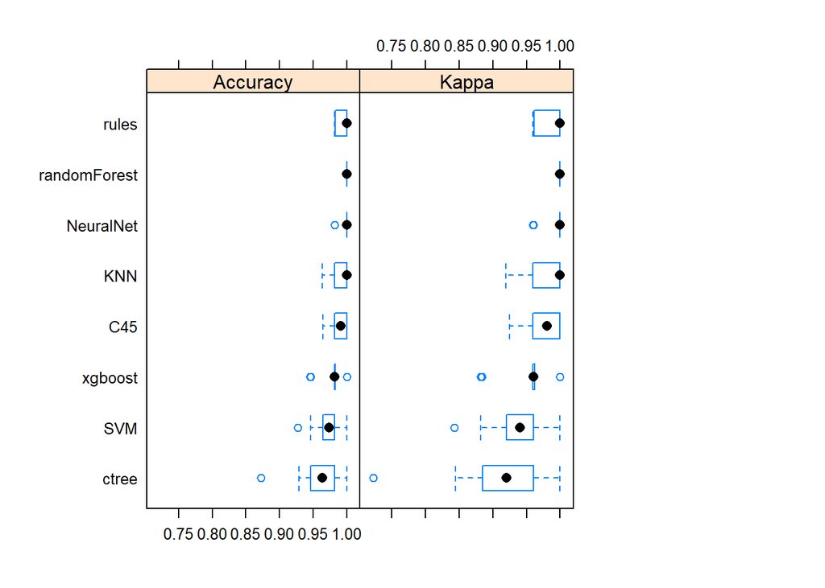

```r
library(lattice)
bwplot(resamps, layout = c(3, 1))
```

```r
difs <- diff(resamps)
difs
```

```
##
## Call:
## diff.resamples(x = resamps)
##
## Models: ctree, C45, SVM, KNN, rules, randomForest, xgboost, NeuralNet
## Metrics: Accuracy, Kappa
## Number of differences: 28
## p-value adjustment: bonferroni
```

```r
summary(difs)
```

```
##
## Call:
## summary.diff.resamples(object = difs)
##
## p-value adjustment: bonferroni
## Upper diagonal: estimates of the difference
## Lower diagonal: p-value for H0: difference = 0
##
## Accuracy
##              ctree   C45       SVM       KNN       rules     randomForest
## ctree                -0.032340 -0.012599 -0.034031 -0.037666 -0.043057
## C45          0.53129            0.019741 -0.001691 -0.005326 -0.010717
## SVM          1.00000 0.67133             -0.021432 -0.025067 -0.030458
## KNN          0.20097 1.00000   0.24159             -0.003635 -0.009026
## rules        0.14435 1.00000   0.07586   1.00000             -0.005391
## randomForest 0.13041 0.64481   0.03633   1.00000   1.00000
## xgboost      0.70024 1.00000   1.00000   1.00000   0.23830   0.05556
## NeuralNet    0.14093 1.00000   0.02506   1.00000   1.00000   1.00000
##              xgboost   NeuralNet
## ctree        -0.019743 -0.039453
## C45           0.012597 -0.007113
## SVM          -0.007144 -0.026854
## KNN           0.014288 -0.005422
## rules         0.017923 -0.001787
## randomForest  0.023314  0.003604
## xgboost                -0.019710
## NeuralNet    0.09155
##
## Kappa
##              ctree   C45       SVM       KNN       rules     randomForest
## ctree                -0.070574 -0.027112 -0.074034 -0.082175 -0.094113
## C45          0.51902            0.043462 -0.003460 -0.011601 -0.023539
## SVM          1.00000 0.63732             -0.046922 -0.055063 -0.067001
## KNN          0.20297 1.00000   0.25402             -0.008141 -0.020079
## rules        0.13903 1.00000   0.06821   1.00000             -0.011938
## randomForest 0.12734 0.61723   0.03299   1.00000   1.00000
## xgboost      0.73116 1.00000   0.98830   1.00000   0.23670   0.05183
## NeuralNet    0.13950 1.00000   0.02329   1.00000   1.00000   1.00000
##              xgboost   NeuralNet
## ctree        -0.043217 -0.086108
## C45           0.027357 -0.015533
## SVM          -0.016105 -0.058996
## KNN           0.030817 -0.012073
## rules         0.038958 -0.003933
## randomForest  0.050896  0.008006
## xgboost                -0.042891
## NeuralNet    0.09218
```

**Prediccion y matriz de confusion**

```r
dt_pred <- predict(ctreeFit, cancer_test)
dt_pred
```

```
##   [1] 2 4 2 2 4 2 2 4 4 2 4 2 4 2 4 2 2 2 2 2 4 2 4 4 2 4 4 2 2 2 4 4 2 2 4 2 4
##  [38] 4 2 2 2 2 2 2 4 4 4 2 2 2 2 4 4 2 2 4 2 4 2 2 4 2 2 4 4 4 4 4 4 4 4 4 2 4
##  [75] 2 2 2 2 2 4 2 2 4 2 2 2 4 2 2 2 2 4 2 2 4 4 4 2 2 4 2 2 2 2 2 2 2 2 2 2 4
## [112] 4 2 2 2 4 2 2 4 4 2 2 2 2 2 4 2 2 2 2 2 2 2 2 4 2 2 2 4
## Levels: 2 4
```

*Matriz de confusion*

```r
confusionMatrix(dt_pred,factor(cancer_test$Clases))
```

```
## Confusion Matrix and Statistics
##
##           Reference
## Prediction  2  4
##          2 87  1
##          4  4 47
##
##                Accuracy : 0.964
##                  95% CI : (0.9181, 0.9882)
##     No Information Rate : 0.6547
##     P-Value [Acc > NIR] : <2e-16
##
##                   Kappa : 0.9216
##
##  Mcnemar's Test P-Value : 0.3711
##
##             Sensitivity : 0.9560
##             Specificity : 0.9792
##          Pos Pred Value : 0.9886
##          Neg Pred Value : 0.9216
##              Prevalence : 0.6547
##          Detection Rate : 0.6259
##    Detection Prevalence : 0.6331
##       Balanced Accuracy : 0.9676
##
##        'Positive' Class : 2
##
```

```r
# https://rpubs.com/chzelada/275494
```

*Random forest*

```r
rf_pred <- predict(randomForestFit, cancer_test)
rf_pred
```

```
##   [1] 2 4 2 2 4 2 2 4 4 2 4 4 4 2 4 2 2 2 2 2 4 2 4 4 2 4 4 2 2 2 4 4 2 2 4 2 4
##  [38] 4 2 2 2 2 2 2 4 4 4 2 2 2 2 4 4 2 2 4 2 4 2 2 4 2 2 4 4 4 4 4 4 4 4 4 2 4
##  [75] 2 2 2 2 2 4 2 2 4 2 2 2 4 2 2 2 2 4 2 2 4 4 4 2 2 4 2 2 2 2 2 2 2 2 2 2 4
## [112] 4 2 2 2 4 2 2 4 4 2 2 2 2 2 4 2 2 2 2 2 2 2 2 4 2 2 2 4
## Levels: 2 4
```

*Matriz de confusion*

```r
confusionMatrix(rf_pred,factor(cancer_test$Clases))
```

```
## Confusion Matrix and Statistics
##
##           Reference
## Prediction  2  4
##          2 87  0
##          4  4 48
##
##                Accuracy : 0.9712
##                  95% CI : (0.928, 0.9921)
##     No Information Rate : 0.6547
##     P-Value [Acc > NIR] : <2e-16
##
##                   Kappa : 0.9376
##
##  Mcnemar's Test P-Value : 0.1336
##
##             Sensitivity : 0.9560
##             Specificity : 1.0000
##          Pos Pred Value : 1.0000
##          Neg Pred Value : 0.9231
##              Prevalence : 0.6547
##          Detection Rate : 0.6259
##    Detection Prevalence : 0.6259
##       Balanced Accuracy : 0.9780
##
##        'Positive' Class : 2
##
```

```r
# https://rpubs.com/chzelada/275494
```

```r
#https://www.positioniseverything.net/error-data-and-reference-should-be-factors-with-the-same-levels/
```

**CREANDO MODELOS CON OTRAS LIBRERIAS Y GRAFICANDO RESULTADOS**

```r
library(tidyverse)
library(ggplot2)
library(caret)

decisionplot <- function(model, data, class_var,
  predict_type = c("class", "prob"), resolution = 5 * 75) {

      # resolution is set to 75 dpi if the image is rendered 5 inces wide.
      y <- data %>% pull(class_var)
      x <- data %>% dplyr::select(-all_of(class_var))

      # resubstitution accuracy
      prediction <- predict(model, x, type = predict_type[1])

      # LDA returns a list
      if(is.list(prediction)) prediction <- prediction$class
      prediction <- factor(prediction, levels = levels(y))
      cm <- confusionMatrix(data = prediction, reference = y)
      acc <- cm$overall["Accuracy"]

      # evaluate model on a grid
      r <- sapply(x[, 1:2], range, na.rm = TRUE)
      xs <- seq(r[1,1], r[2,1], length.out = resolution)
      ys <- seq(r[1,2], r[2,2], length.out = resolution)
      g <- cbind(rep(xs, each = resolution), rep(ys, time = resolution))
      colnames(g) <- colnames(r)
      g <- as_tibble(g)

      ### guess how to get class labels from predict
      ### (unfortunately not very consistent between models)
      cl <- predict(model, g, type = predict_type[1])

      # LDA returns a list
      if(is.list(cl)) {
      prob <- cl$posterior
      cl <- cl$class
      } else
      try(prob <- predict(model, g, type = predict_type[2]))

      # we visualize the difference in probability/score between the
      # winning class and the second best class.
      # don't use probability if predict for the classifier does not support it.
      max_prob <- 1
      try({
      max_prob <- t(apply(prob, MARGIN = 1, sort, decreasing = TRUE))
      max_prob <- max_prob[,1] - max_prob[,2]
      }, silent = TRUE)
      cl <- factor(cl, levels = levels(y))
      g <- g %>% add_column(prediction = cl, probability = max_prob)
      ggplot(g, mapping = aes_string(
      x = colnames(g)[1],
      y = colnames(g)[2])) +
        geom_raster(mapping = aes(fill = prediction, alpha = probability)) +
      geom_contour(mapping = aes(z = as.numeric(prediction)),
      bins = length(levels(cl)), size = .5, color = "black") +
      geom_point(data = data, mapping = aes_string(
      x = colnames(data)[1],
      y = colnames(data)[2],
      shape = class_var), alpha = .7) +
      scale_alpha_continuous(range = c(0,1), limits = c(0,1), guide = "none") +
      labs(subtitle = paste("Training accuracy:", round(acc, 2)))
  }
```

```r
dataset_cancer <- as_tibble(dataset_cancer)
x <- dataset_cancer %>% dplyr::select(Espesor_grupo_celulas, Uniformiformidad_tamanio_celular, Clases)
x$Clases<- as.factor(x$Clases)
```

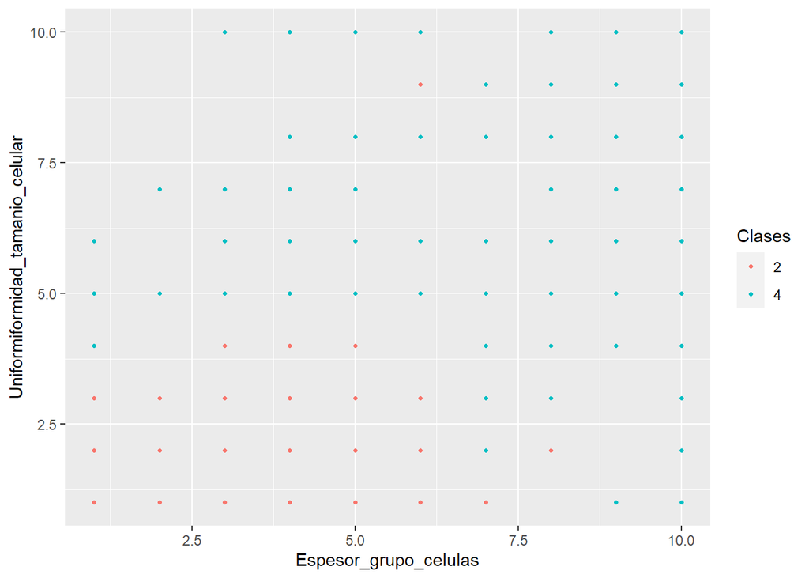

```r
ggplot() + geom_point(data = dataset_cancer, aes(Espesor_grupo_celulas, Uniformiformidad_tamanio_celular, color = Clases), size = 0.9)
```

*Clasificador K-Nearest Neighbors*

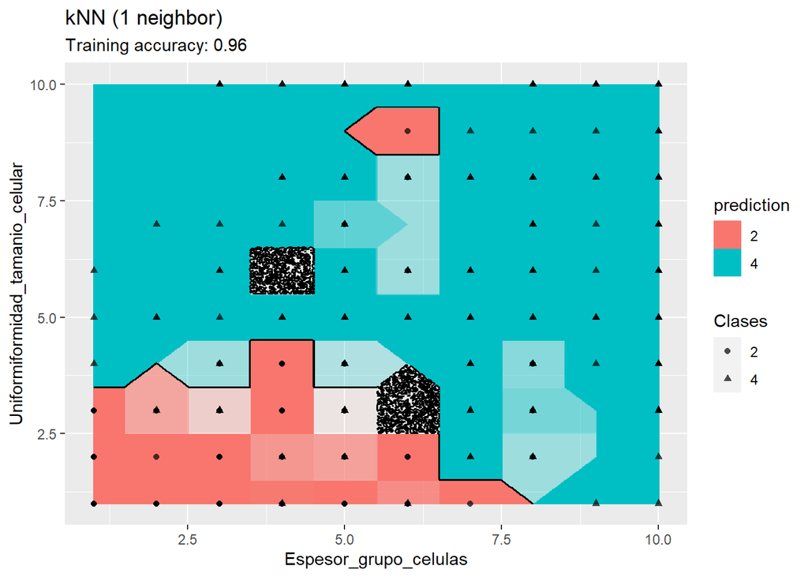

```r
library(caret)
model <- x %>% knn3(Clases ~ ., data = ., k = 1)
decisionplot(model, x, class_var = "Clases") + labs(title = "kNN (1 neighbor)")
```

[figure not shown]

```r
model <- x %>% knn3(Clases ~ ., data = ., k = 6)
decisionplot(model, x, class_var = "Clases") + labs(title = "kNN (1 neighbor)")
```

[figure not shown]

```r
model <- x %>% knn3(Clases ~ ., data = ., k = 10)
decisionplot(model, x, class_var = "Clases") + labs(title = "kNN (1 neighbor)")
```

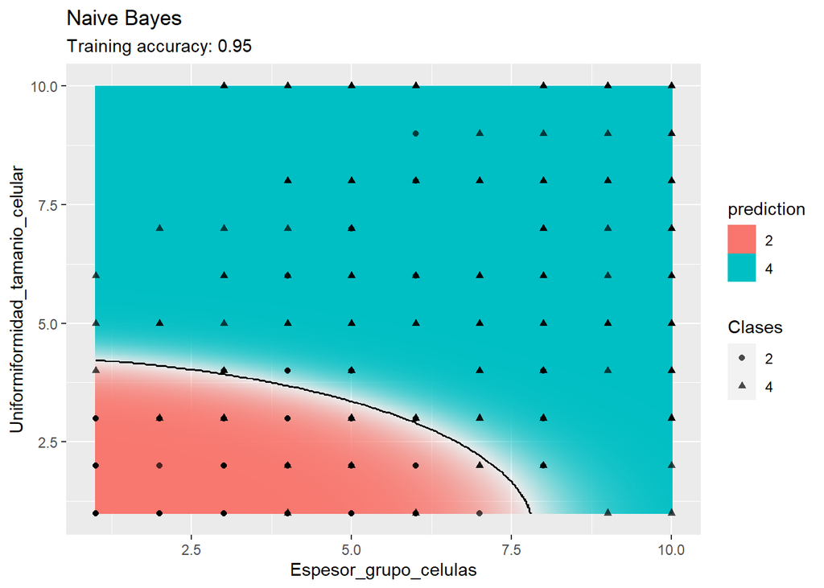

```r
library(e1071)
model <- x %>% naiveBayes(Clases ~ ., data = .)
decisionplot(model, x, class_var = "Clases", predict_type = c("class", "raw")) + labs(title
= "Naive Bayes")
```

```r
library(MASS)
```

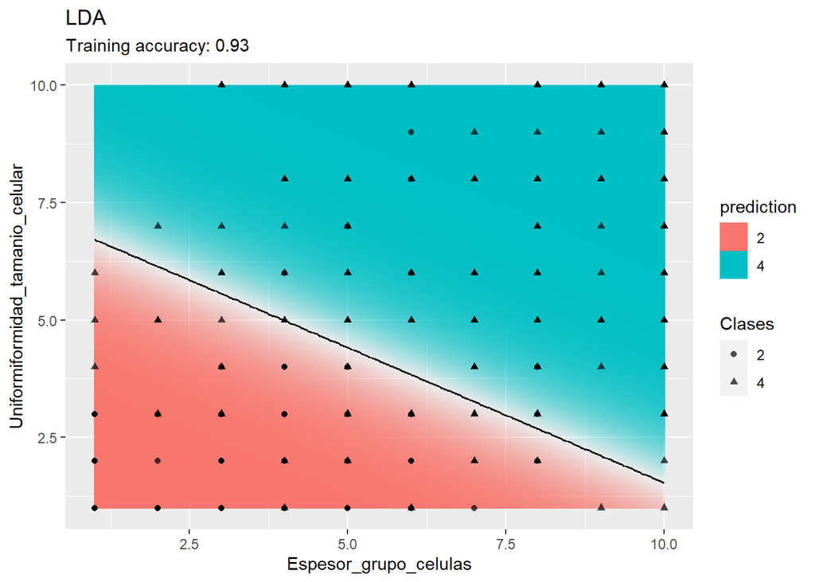

```r
model <- x %>% lda(Clases ~ ., data = .)
decisionplot(model, x, class_var = "Clases") + labs(title = "LDA")
```

```r
library(nnet)
model <- x %>% multinom(Clases ~., data = .)
```

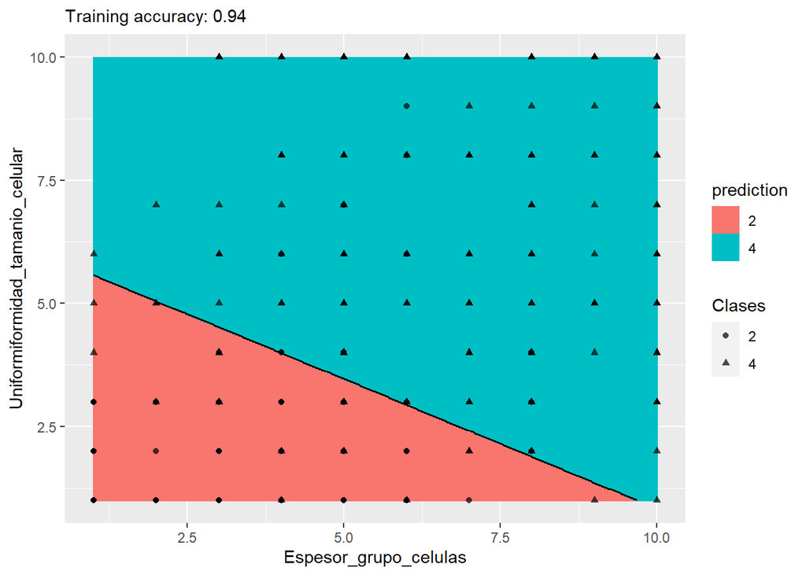

```r
decisionplot(model, x, class_var = "Clases") + labs(titel = "Multinomial Logistic Regressio
n")
```

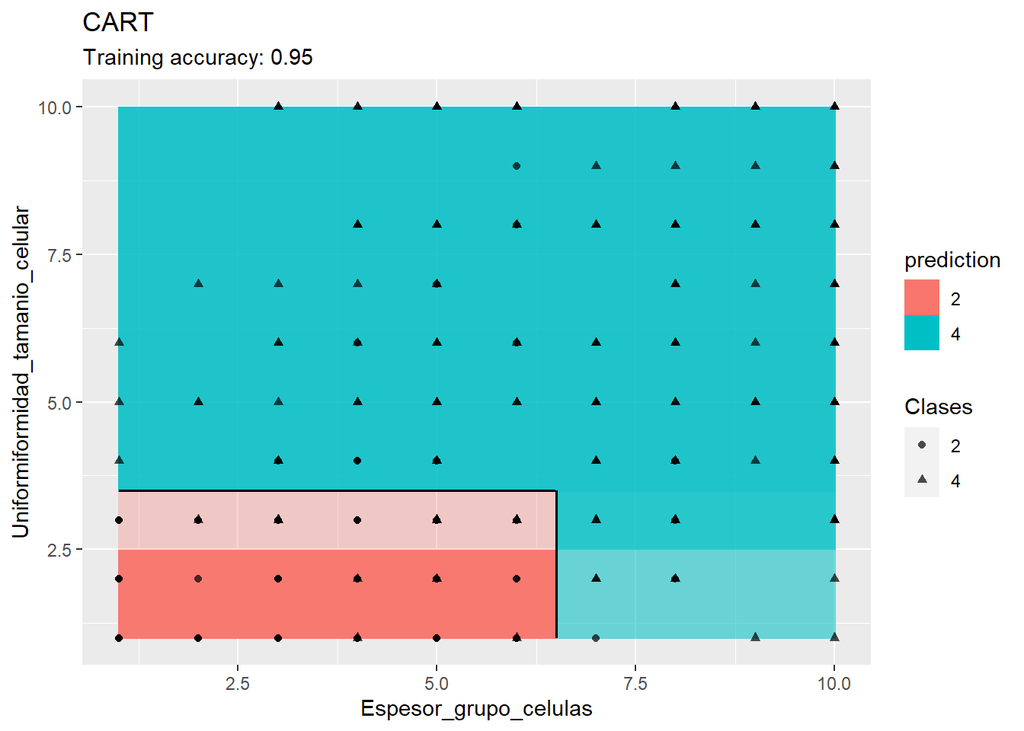

```r
library("rpart")
model <- x %>% rpart(Clases ~ ., data = .)
decisionplot(model, x, class_var = "Clases") + labs(title = "CART")
```

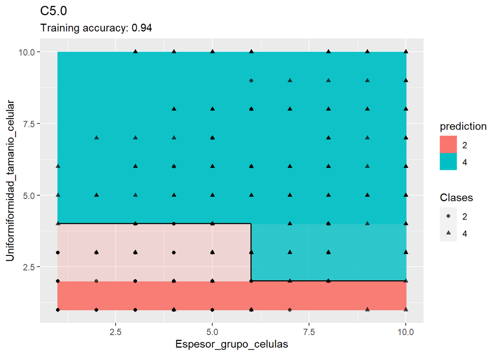

```r
library(C50)
model <- x %>% C5.0(Clases ~ ., data = .)
decisionplot(model, x, class_var = "Clases") + labs(title = "C5.0")
```

```r
library(randomForest)
```

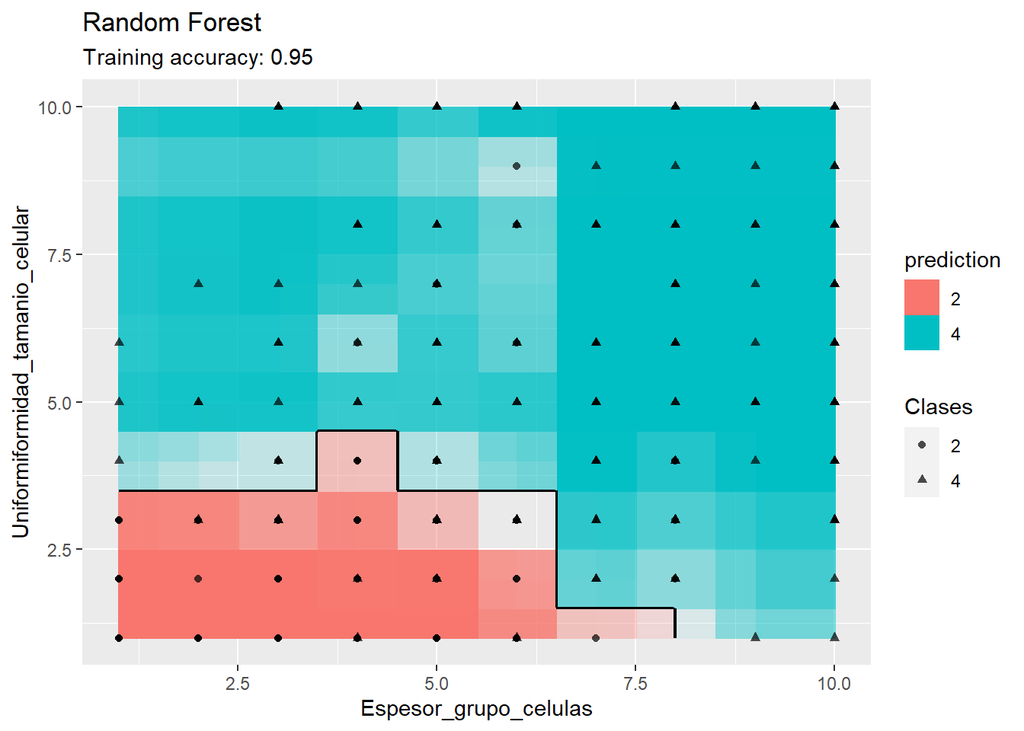

```r
model <- x %>% randomForest(Clases ~ ., data = .)
decisionplot(model, x, class_var = "Clases") + labs(title = "Random Forest")
```

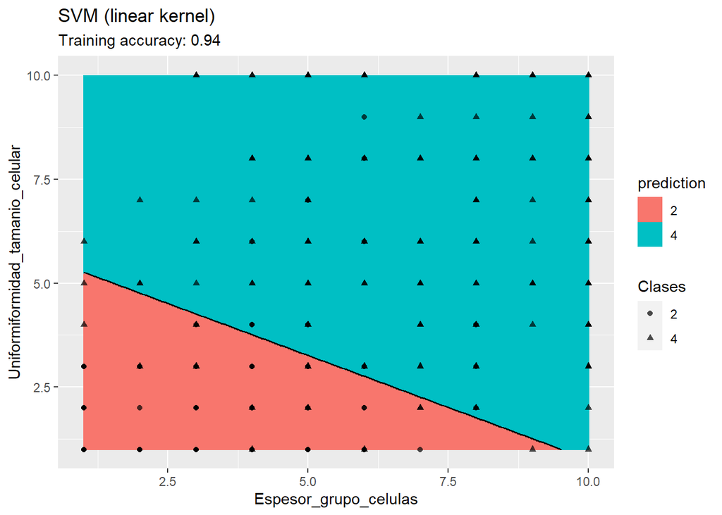

```r
library(e1071)
model <- x %>% svm(Clases ~ ., data = ., kernel = "linear")
decisionplot(model, x, class_var = "Clases") + labs(title = "SVM (linear kernel)")
```

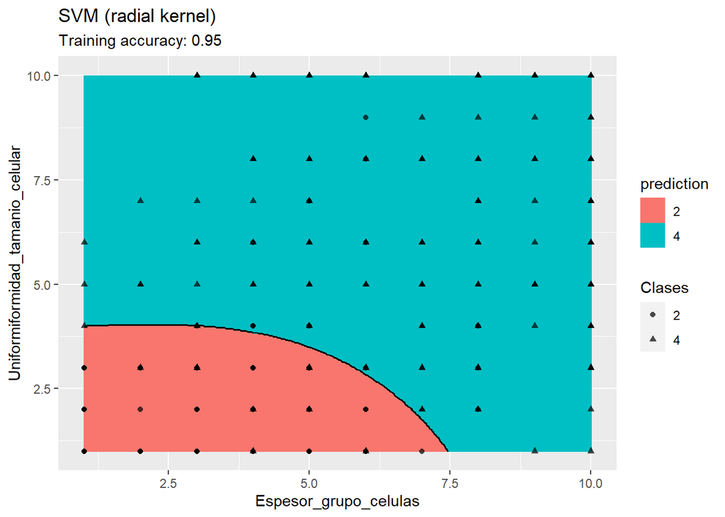

```r
model <- x %>% svm(Clases ~ ., data = ., kernel = "radial")
decisionplot(model, x, class_var = "Clases") + labs(title = "SVM (radial kernel)")
```

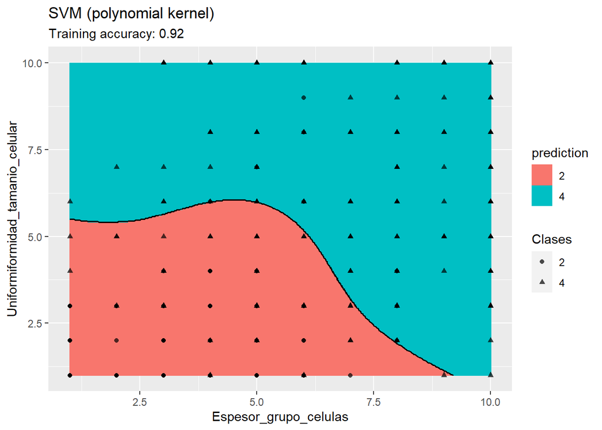

```r
model <- x %>% svm(Clases ~ ., data = ., kernel = "polynomial")
decisionplot(model, x, class_var = "Clases") + labs(title = "SVM (polynomial kernel)")
```

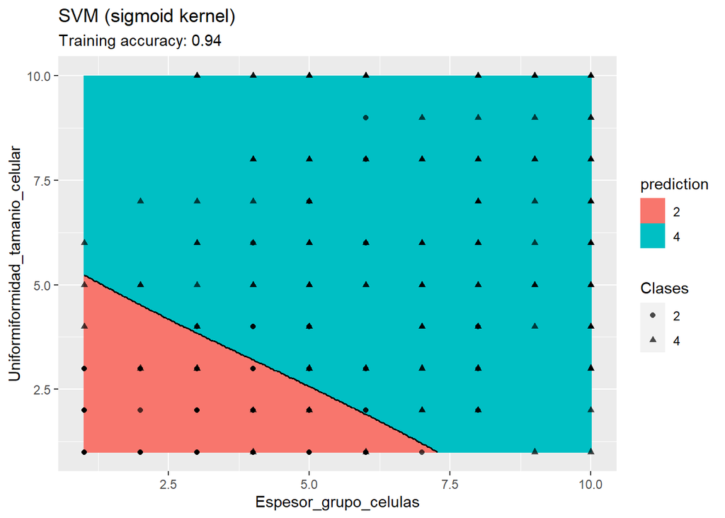

```r
model <- x %>% svm(Clases ~ ., data = ., kernel = "sigmoid")
decisionplot(model, x, class_var = "Clases") + labs(title = "SVM (sigmoid kernel)")
```

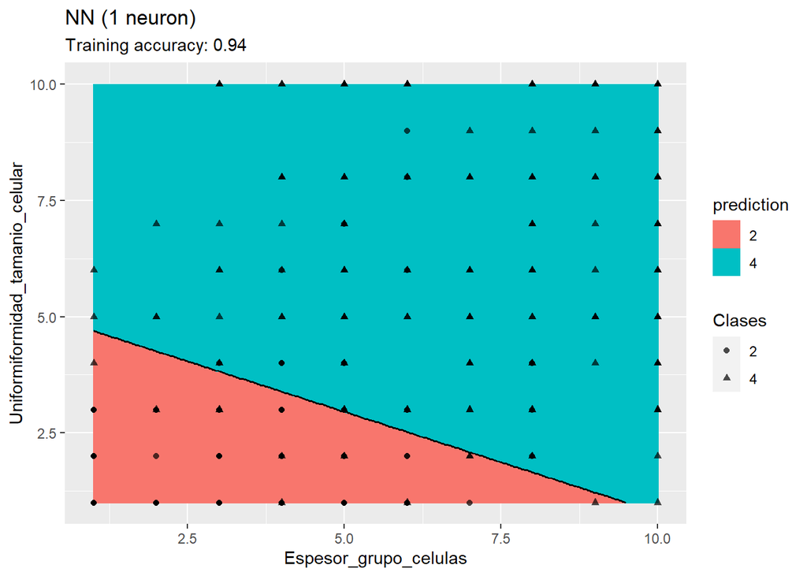

```r
library(nnet)
model <-x %>% nnet(Clases ~ ., data = ., size = 1, maxit = 1000, trace = FALSE)
decisionplot(model, x, class_var = "Clases",
predict_type = c("class", "raw")) + labs(title = "NN (1 neuron)")
```

[figure not shown]

```r
model <-x %>% nnet(Clases ~ ., data = ., size = 15, maxit = 1000, trace = FALSE)
decisionplot(model, x, class_var = "Clases",
predict_type = c("class", "raw")) + labs(title = "NN (4 neurons)")
```

# CLASIFICACION

CARLOS ALEX NINA GUARDAPUCLLA

2023-01-07

**Análisis comparativo de las técnicas de clasificación**

**Tabla de contenido**

**1. - IMPORTACION DE BIBLIOTECAS**

```r
library(tidyverse)
library(caret)
```

```r
library(ggcorrplot)
library(lattice)
library(RWeka)
library(party)
library(dplyr)
library(plotly)
library(ggplot2)
library(reshape2)
library(ggthemes)
library(DataExplorer)
library(psych)
library(ggcorrplot)
library(FactoMineR)
library(factoextra)
```

**2. - CARGA DE DATOS**

*Cargando el conjunto de datos*

```r
dataset_cancer<-read.table(file="datos/breast-cancer-wisconsin.data", header = TRUE, sep = ",")
```

*Mostrar contenido del dataset*

```r
# MOSTRAR LAS PRIMERAS FILAS
dataset_cancer <- as_tibble(dataset_cancer)
head(dataset_cancer)
```

```
## # A tibble: 6 × 11
##   X1000025    X5    X1  X1.1  X1.2    X2 X1.3     X3  X1.4  X1.5  X2.1
##      <int> <int> <int> <int> <int> <int> <chr> <int> <int> <int> <int>
## 1  1002945     5     4     4     5     7 10        3     2     1     2
## 2  1015425     3     1     1     1     2 2         3     1     1     2
## 3  1016277     6     8     8     1     3 4         3     7     1     2
## 4  1017023     4     1     1     3     2 1         3     1     1     2
## 5  1017122     8    10    10     8     7 10        9     7     1     4
## 6  1018099     1     1     1     1     2 10        3     1     1     2
```

```r
# MOSTRAR LAS ULTIMAS FILAS
tail(dataset_cancer)
```

```
## # A tibble: 6 × 11
##   X1000025    X5    X1  X1.1  X1.2    X2 X1.3     X3  X1.4  X1.5  X2.1
##      <int> <int> <int> <int> <int> <int> <chr> <int> <int> <int> <int>
## 1   763235     3     1     1     1     2 1         2     1     2     2
## 2   776715     3     1     1     1     3 2         1     1     1     2
## 3   841769     2     1     1     1     2 1         1     1     1     2
## 4   888820     5    10    10     3     7 3         8    10     2     4
## 5   897471     4     8     6     4     3 4        10     6     1     4
## 6   897471     4     8     8     5     4 5        10     4     1     4
```

*-La primera columna corresponde al ID el cual no aporta informacion relevante para los posteriores procesos a realizar*

**3. - LIMPIEZA DE DATOS**

*Eliminando contenido poco relevante*

```r
# Eliminando columna con id's
dataset_temp <- dataset_cancer[,-c(1)]
head(dataset_temp)
```

```
## # A tibble: 6 × 10
##      X5    X1  X1.1  X1.2    X2 X1.3     X3  X1.4  X1.5  X2.1
##   <int> <int> <int> <int> <int> <chr> <int> <int> <int> <int>
## 1     5     4     4     5     7 10        3     2     1     2
## 2     3     1     1     1     2 2         3     1     1     2
## 3     6     8     8     1     3 4         3     7     1     2
## 4     4     1     1     3     2 1         3     1     1     2
## 5     8    10    10     8     7 10        9     7     1     4
## 6     1     1     1     1     2 10        3     1     1     2
```

*- Se observa que las columnas no tienen un nombre adecuado, por lo tanto se debe proceder a renombrarlas*

**4. - PREPROCESAMIENTO DE DATOS**

*Renombrando las columnas*

```r
dataset_cancer <- dataset_temp
names(dataset_cancer) <- c("Espesor_grupo_celulas", "Uniformiformidad_tamanio_celular", "Uniformiformidad_forma_celular",   "Adhesion_marginal","Tamanio_celula_epitelial","Nucleos_desnudos", "Cromatina_blanda","Nucleolos_normales","Mitosis","Clases")
rownames(dataset_cancer) <- NULL # resetear los indices
head(dataset_cancer)
```

```
## # A tibble: 6 × 10
##   Espes…¹ Unifo…² Unifo…³ Adhes…⁴ Taman…⁵ Nucle…⁶ Croma…⁷ Nucle…⁸ Mitosis Clases
##     <int>   <int>   <int>   <int>   <int> <chr>     <int>   <int>   <int>  <int>
## 1       5       4       4       5       7 10            3       2       1      2
## 2       3       1       1       1       2 2             3       1       1      2
## 3       6       8       8       1       3 4             3       7       1      2
## 4       4       1       1       3       2 1             3       1       1      2
## 5       8      10      10       8       7 10            9       7       1      4
## 6       1       1       1       1       2 10            3       1       1      2
## # … with abbreviated variable names ¹Espesor_grupo_celulas,
## #   ²Uniformiformidad_tamanio_celular, ³Uniformiformidad_forma_celular,
## #   ⁴Adhesion_marginal, ⁵Tamanio_celula_epitelial, ⁶Nucleos_desnudos,
## #   ⁷Cromatina_blanda, ⁸Nucleolos_normales
```

*Identificacion y tratamiento de datos nulos*

```r
# Verificar si existen datos nulos
colSums(is.na(dataset_cancer))
```

```
##            Espesor_grupo_celulas Uniformiformidad_tamanio_celular
##                                0                                0
##   Uniformiformidad_forma_celular                Adhesion_marginal
##                                0                                0
##         Tamanio_celula_epitelial                 Nucleos_desnudos
##                                0                                0
##                 Cromatina_blanda               Nucleolos_normales
##                                0                                0
##                          Mitosis                           Clases
##                                0                                0
```

*- Se observa que no hay presencia de datos nulos o faltantes*

```r
# Mostrar descripcion del dataset
str(dataset_cancer)
```

```
## tibble [698 × 10] (S3: tbl_df/tbl/data.frame)
##  $ Espesor_grupo_celulas           : int [1:698] 5 3 6 4 8 1 2 2 4 1 ...
##  $ Uniformiformidad_tamanio_celular: int [1:698] 4 1 8 1 10 1 1 1 2 1 ...
##  $ Uniformiformidad_forma_celular  : int [1:698] 4 1 8 1 10 1 2 1 1 1 ...
##  $ Adhesion_marginal               : int [1:698] 5 1 1 3 8 1 1 1 1 1 ...
##  $ Tamanio_celula_epitelial        : int [1:698] 7 2 3 2 7 2 2 2 2 1 ...
##  $ Nucleos_desnudos                : chr [1:698] "10" "2" "4" "1" ...
##  $ Cromatina_blanda                : int [1:698] 3 3 3 3 9 3 3 1 2 3 ...
##  $ Nucleolos_normales              : int [1:698] 2 1 7 1 7 1 1 1 1 1 ...
##  $ Mitosis                         : int [1:698] 1 1 1 1 1 1 1 5 1 1 ...
##  $ Clases                          : int [1:698] 2 2 2 2 4 2 2 2 2 2 ...
```

```r
# Mostrar resumen estadistico de las columnas
summary(dataset_cancer)
```

```
##  Espesor_grupo_celulas Uniformiformidad_tamanio_celular
##  Min.   : 1.000        Min.   : 1.000
##  1st Qu.: 2.000        1st Qu.: 1.000
##  Median : 4.000        Median : 1.000
##  Mean   : 4.417        Mean   : 3.138
##  3rd Qu.: 6.000        3rd Qu.: 5.000
##  Max.   :10.000        Max.   :10.000
##  Uniformiformidad_forma_celular Adhesion_marginal Tamanio_celula_epitelial
##  Min.   : 1.000                 Min.   : 1.000    Min.   : 1.000
##  1st Qu.: 1.000                 1st Qu.: 1.000    1st Qu.: 2.000
##  Median : 1.000                 Median : 1.000    Median : 2.000
##  Mean   : 3.211                 Mean   : 2.809    Mean   : 3.218
##  3rd Qu.: 5.000                 3rd Qu.: 4.000    3rd Qu.: 4.000
##  Max.   :10.000                 Max.   :10.000    Max.   :10.000
##  Nucleos_desnudos   Cromatina_blanda Nucleolos_normales    Mitosis
##  Length:698         Min.   : 1.000   Min.   : 1.00      Min.   : 1.00
##  Class :character   1st Qu.: 2.000   1st Qu.: 1.00      1st Qu.: 1.00
##  Mode  :character   Median : 3.000   Median : 1.00      Median : 1.00
##                     Mean   : 3.438   Mean   : 2.87      Mean   : 1.59
##                     3rd Qu.: 5.000   3rd Qu.: 4.00      3rd Qu.: 1.00
##                     Max.   :10.000   Max.   :10.00      Max.   :10.00
##      Clases
##  Min.   :2.000
##  1st Qu.:2.000
##  Median :2.000
##  Mean   :2.691
##  3rd Qu.:4.000
##  Max.   :4.000
```

*Mostrar datos únicos de cada columna*

```r
sapply(dataset_cancer, unique)
```

```
## $Espesor_grupo_celulas
##  [1]  5  3  6  4  8  1  2  7 10  9
##
## $Uniformiformidad_tamanio_celular
##  [1]  4  1  8 10  2  3  7  5  6  9
##
## $Uniformiformidad_forma_celular
##  [1]  4  1  8 10  2  3  5  6  7  9
##
## $Adhesion_marginal
##  [1]  5  1  3  8 10  4  6  2  9  7
##
## $Tamanio_celula_epitelial
##  [1]  7  2  3  1  6  4  5  8 10  9
##
## $Nucleos_desnudos
##  [1] "10" "2"  "4"  "1"  "3"  "9"  "7"  "?"  "5"  "8"  "6"
##
## $Cromatina_blanda
##  [1]  3  9  1  2  4  5  7  8  6 10
##
## $Nucleolos_normales
##  [1]  2  1  7  4  5  3 10  6  9  8
##
## $Mitosis
## [1]  1  5  4  2  3  7 10  8  6
##
## $Clases
## [1] 2 4
```

*- Se observa que la columna “Nucleos_desnudos” es de tipo caracter y posee caracteres que no corresponde con la mayoria de datos*

*Reemplazar “?” de la columna “Nucleos_desnudos” por la moda de la misma*

```r
# Obtener la moda de dicha columna
mode <- function(x) {
   return(as.numeric(names(which.max(table(x)))))
}
moda_Nucleos_desnudos = mode(dataset_cancer$Nucleos_desnudos)
moda_Nucleos_desnudos
```

```
## [1] 1
```

```r
# Tratamiento de caracter extraño
dataset_cancer$Nucleos_desnudos[dataset_cancer$Nucleos_desnudos=="?"] <- moda_Nucleos_desnudos

# corregir el tipo de dato de dicha columna "Nucleos_desnudos"
dataset_cancer$Nucleos_desnudos<- as.integer(dataset_cancer$Nucleos_desnudos)

# corregir el tipo de dato de la columna "clase"
dataset_cancer$Clases<- as.factor(dataset_cancer$Clases)
```

```r
unique(dataset_cancer$Nucleos_desnudos)
```

```
##  [1] 10  2  4  1  3  9  7  5  8  6
```

*- Se observa que dicho caracter fue eliminado y el tipo de dato fue corregido*

*Visualizando la distribucion de los datos mediante el histograma*

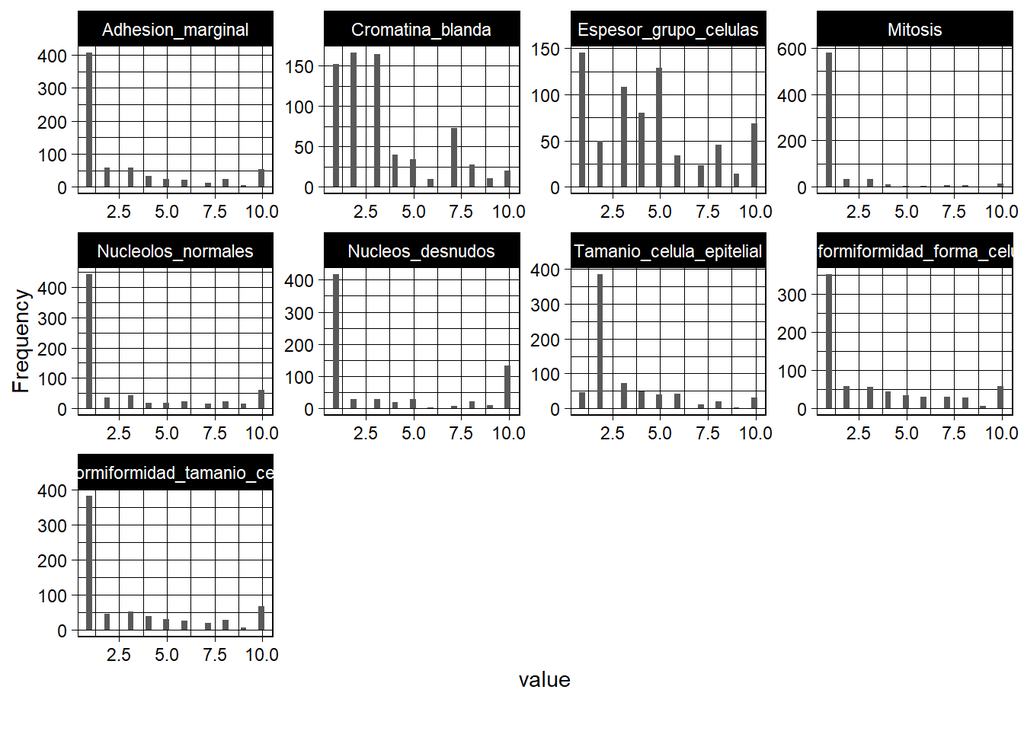

```r
plot_histogram(dataset_cancer,ggtheme = theme_linedraw())
```

**5.- ESCALAR LOS DATOS**

*- Se procede a normalizar los datos para trabajar en una misma escala*

```r
# Crear una copia del dataset limpio
dataset_scale <- dataset_cancer
```

```r
# Escalar las columnas numéricas
dataset_scale <- dataset_scale[,1:9]
dataset_scale <- scale(dataset_scale)
dataset_scale <- data.frame(dataset_scale)
# Agregando nuevamente la columna "Clases" al dataset escalado
dataset_scale <- mutate(dataset_scale, Clases = dataset_cancer$Clases)
summary(dataset_scale)
```

```
##  Espesor_grupo_celulas Uniformiformidad_tamanio_celular
##  Min.   :-1.2127       Min.   :-0.7002
##  1st Qu.:-0.8578       1st Qu.:-0.7002
##  Median :-0.1480       Median :-0.7002
##  Mean   : 0.0000       Mean   : 0.0000
##  3rd Qu.: 0.5618       3rd Qu.: 0.6101
##  Max.   : 1.9815       Max.   : 2.2481
##  Uniformiformidad_forma_celular Adhesion_marginal Tamanio_celula_epitelial
##  Min.   :-0.7436                Min.   :-0.6334   Min.   :-1.0011
##  1st Qu.:-0.7436                1st Qu.:-0.6334   1st Qu.:-0.5497
##  Median :-0.7436                Median :-0.6334   Median :-0.5497
##  Mean   : 0.0000                Mean   : 0.0000   Mean   : 0.0000
##  3rd Qu.: 0.6019                3rd Qu.: 0.4168   3rd Qu.: 0.3531
##  Max.   : 2.2838                Max.   : 2.5172   Max.   : 3.0614
##  Nucleos_desnudos  Cromatina_blanda  Nucleolos_normales    Mitosis
##  Min.   :-0.6872   Min.   :-0.9993   Min.   :-0.612     Min.   :-0.3439
##  1st Qu.:-0.6872   1st Qu.:-0.5895   1st Qu.:-0.612     1st Qu.:-0.3439
##  Median :-0.6872   Median :-0.1797   Median :-0.612     Median :-0.3439
##  Mean   : 0.0000   Mean   : 0.0000   Mean   : 0.000     Mean   : 0.0000
##  3rd Qu.: 0.4168   3rd Qu.: 0.6400   3rd Qu.: 0.370     3rd Qu.:-0.3439
##  Max.   : 1.7967   Max.   : 2.6891   Max.   : 2.334     Max.   : 4.9003
##  Clases
##  2:457
##  4:241
##
##
##
##
```

*Análisis de correlacion*

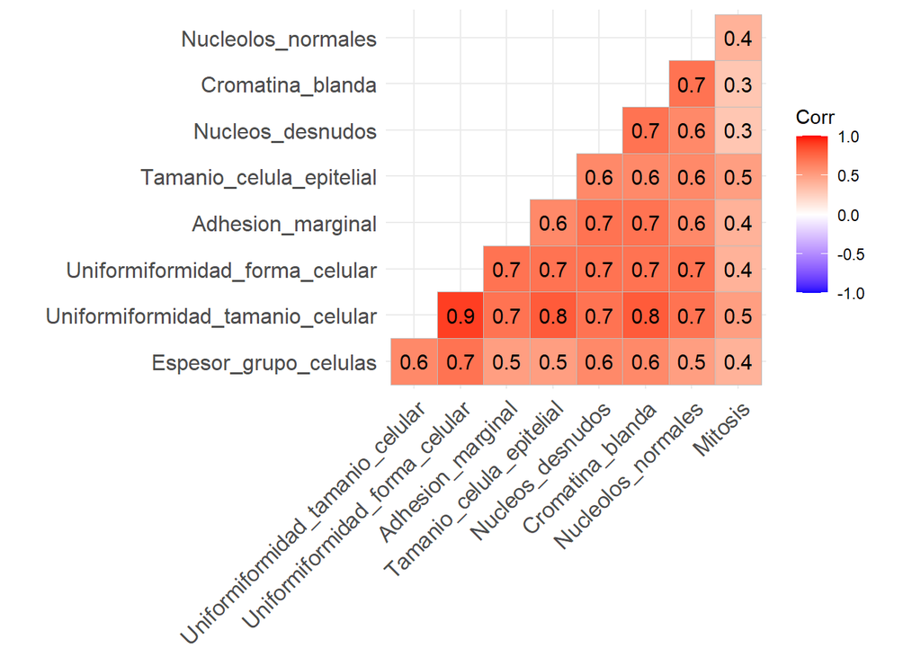

```r
ggcorrplot(round(cor(dataset_scale[,1:9]), 1), type = "lower", lab = T, show.legend = T,tl.srt=45)
```

*- Todas las variables presentan una correlacion positiva”*

*- Mitosis es una variable que presenta baja correlacion respecto a las demas variables”*

*- Se observa una correlacion positiva alta entre las variables “Uniformidad_forma_celular” y “Uniformidad_tamanio_celular”*

**6.- ANÁLISIS DE COMPONENTES PRINCIPALES (PCA)**

```r
dataset_scale_PCA.pca <- PCA(dataset_scale[,1:9], graph=FALSE)
print(dataset_scale_PCA.pca)
```

```
## **Results for the Principal Component Analysis (PCA)**
## The analysis was performed on 698 individuals, described by 9 variables
## *The results are available in the following objects:
##
##    name               description
## 1  "$eig"             "eigenvalues"
## 2  "$var"             "results for the variables"
## 3  "$var$coord"       "coord. for the variables"
## 4  "$var$cor"         "correlations variables - dimensions"
## 5  "$var$cos2"        "cos2 for the variables"
## 6  "$var$contrib"     "contributions of the variables"
## 7  "$ind"             "results for the individuals"
## 8  "$ind$coord"       "coord. for the individuals"
## 9  "$ind$cos2"        "cos2 for the individuals"
## 10 "$ind$contrib"     "contributions of the individuals"
## 11 "$call"            "summary statistics"
## 12 "$call$centre"     "mean of the variables"
## 13 "$call$ecart.type" "standard error of the variables"
## 14 "$call$row.w"      "weights for the individuals"
## 15 "$call$col.w"      "weights for the variables"
```

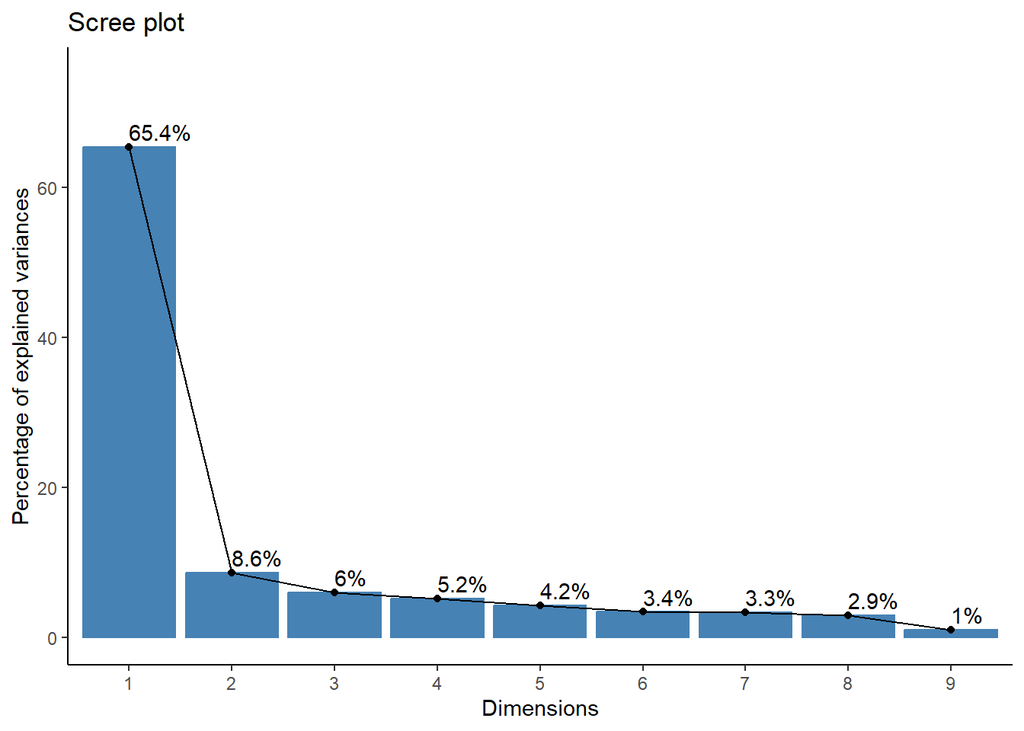

```r
fviz_screeplot(dataset_scale_PCA.pca, addlabels = TRUE, ylim = c(0, 75)) +
  theme_classic()
```

*Se observa que las 2 primeras dimenciones retienen aproximadamente el 74% de las varianzas contenidas en el conjunto de datos.*

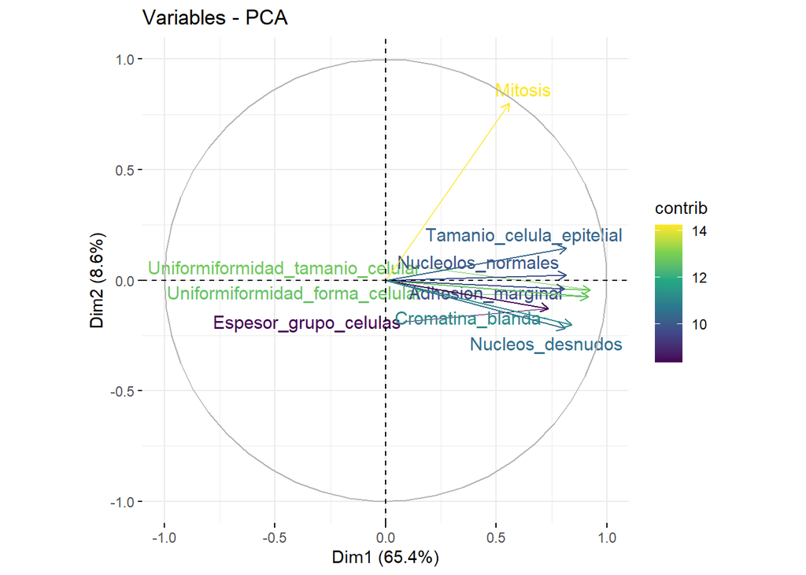

```r
fviz_pca_var(dataset_scale_PCA.pca, col.var="contrib",
             repel = TRUE
             )+scale_colour_viridis_c()
```

*Segun el grafico se observa que la variable “Mitosis” presenta casi una ortogonalidad respecto a algunas variables*

**6.- Clasificación: Técnicas Alternativas**

*Datos de entrenamiento y prueba*

```r
dataset_scale <- data.frame(dataset_scale)
inTrain <- createDataPartition(y = dataset_scale$Clases, p = .8, list = FALSE)
cancer_train <- dataset_scale %>% slice(inTrain)
cancer_test <- dataset_scale %>% slice(-inTrain)
```

- Crear un esquema de muestreo fijo (10 folds)

```r
train_index <- createFolds(cancer_train$Clases, k = 10)
```

*Árbol de inferencia condicional (Árbol de decisión)*

```r
library(rpart)
```

```r
tree_decision <- rpart(Clases ~ ., data = cancer_train, method = "class")
```

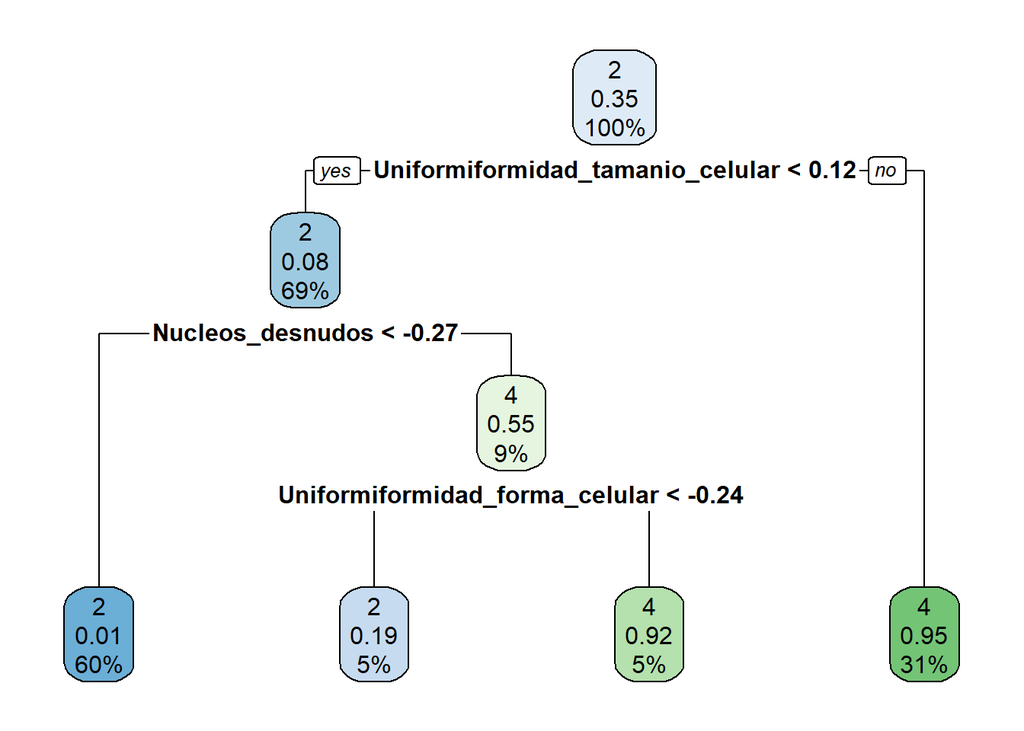

```r
library(rpart.plot)
rpart.plot(tree_decision)
```

```r
# otra forma de crear el arbol de decision

ctreeFit <- cancer_train %>% train(Clases ~ .,
            method = "ctree",
            data = .,
            tuneLength = 5,
            trControl = trainControl(method = "cv", indexOut = train_index))
ctreeFit
```

```
## Conditional Inference Tree
##
## 559 samples
##   9 predictor
##   2 classes: '2', '4'
##
## No pre-processing
## Resampling: Cross-Validated (10 fold)
## Summary of sample sizes: 503, 503, 502, 503, 503, 502, ...
## Resampling results across tuning parameters:
##
##   mincriterion  Accuracy   Kappa
##   0.010         0.9550940  0.9013214
##   0.255         0.9550940  0.9013214
##   0.500         0.9569122  0.9053912
##   0.745         0.9569122  0.9053912
##   0.990         0.9569435  0.9058868
##
## Accuracy was used to select the optimal model using the largest value.
## The final value used for the model was mincriterion = 0.99.
```

[figure not shown]

```r
plot(ctreeFit$finalModel)
```

```r
ctreeFit$finalModel
```

```
##
##   Conditional inference tree with 10 terminal nodes
##
## Response:  .outcome
## Inputs:  Espesor_grupo_celulas, Uniformiformidad_tamanio_celular, Uniformiformidad_forma_celular, Adhesion_marginal, Tamanio_celula_epitelial, Nucleos_desnudos, Cromatina_blanda, Nucleolos_normales, Mitosis
## Number of observations:  559
##
## 1) Uniformiformidad_forma_celular <= -0.07084129; criterion = 1, statistic = 376.862
##   2) Nucleos_desnudos <= 0.416755; criterion = 1, statistic = 214.707
##     3) Uniformiformidad_tamanio_celular <= -0.3726479; criterion = 1, statistic = 124.508
##       4) Nucleos_desnudos <= 0.1407636; criterion = 1, statistic = 47.939
##         5) Cromatina_blanda <= -0.5894927; criterion = 1, statistic = 27.875
##           6)*  weights = 229
##         5) Cromatina_blanda > -0.5894927
##           7) Tamanio_celula_epitelial <= -1.001064; criterion = 1, statistic = 26.295
##             8)*  weights = 7
##           7) Tamanio_celula_epitelial > -1.001064
##             9)*  weights = 85
##       4) Nucleos_desnudos > 0.1407636
##         10)*  weights = 8
##     3) Uniformiformidad_tamanio_celular > -0.3726479
##       11) Espesor_grupo_celulas <= 0.2069419; criterion = 0.995, statistic = 11.759
##         12)*  weights = 21
##       11) Espesor_grupo_celulas > 0.2069419
##         13)*  weights = 8
##   2) Nucleos_desnudos > 0.416755
##     14)*  weights = 18
## 1) Uniformiformidad_forma_celular > -0.07084129
##   15) Uniformiformidad_tamanio_celular <= -0.3726479; criterion = 1, statistic = 29.286
##     16)*  weights = 9
##   15) Uniformiformidad_tamanio_celular > -0.3726479
##     17) Uniformiformidad_tamanio_celular <= 0.2825366; criterion = 0.997, statistic = 12.585
##       18)*  weights = 42
##     17) Uniformiformidad_tamanio_celular > 0.2825366
##       19)*  weights = 132
```

*Además se observa que hay presencia de nodos que presentan alto grado de impureza*

*a) C4.5 Decision Tree*

```r
library(RWeka)
C45Fit <- cancer_train %>% train(Clases ~ .,
            method = "J48",
            data = .,
            tuneLength = 5,
            trControl = trainControl(method = "cv", indexOut = train_index))
C45Fit
```

```
## C4.5-like Trees
##
## 559 samples
##   9 predictor
##   2 classes: '2', '4'
##
## No pre-processing
## Resampling: Cross-Validated (10 fold)
## Summary of sample sizes: 504, 502, 503, 504, 502, 503, ...
## Resampling results across tuning parameters:
##
##   C       M  Accuracy   Kappa
##   0.0100  1  0.9731146  0.9417169
##   0.0100  2  0.9642162  0.9220553
##   0.0100  3  0.9624305  0.9179325
##   0.0100  4  0.9606123  0.9137688
##   0.0100  5  0.9588579  0.9101293
##   0.1325  1  0.9820756  0.9608457
##   0.1325  2  0.9749003  0.9447582
##   0.1325  3  0.9712964  0.9366668
##   0.1325  4  0.9712964  0.9371580
##   0.1325  5  0.9677239  0.9293548
##   0.2550  1  0.9874015  0.9721421
##   0.2550  2  0.9856157  0.9681075
##   0.2550  3  0.9731459  0.9408776
##   0.2550  4  0.9695096  0.9335086
##   0.2550  5  0.9695409  0.9331064
##   0.3775  1  0.9892196  0.9762119
##   0.3775  2  0.9856157  0.9681075
##   0.3775  3  0.9784717  0.9521589
##   0.3775  4  0.9748354  0.9443141
##   0.3775  5  0.9712953  0.9367458
##   0.5000  1  0.9892834  0.9764609
##   0.5000  2  0.9856157  0.9681075
##   0.5000  3  0.9784717  0.9521589
##   0.5000  4  0.9748354  0.9443141
##   0.5000  5  0.9677239  0.9283544
##
## Accuracy was used to select the optimal model using the largest value.
## The final values used for the model were C = 0.5 and M = 1.
```

```r
C45Fit$finalModel
```

```
## J48 pruned tree
## ------------------
##
## Uniformiformidad_tamanio_celular <= -0.372648
## |   Nucleos_desnudos <= -0.411219: 2 (314.0/1.0)
## |   Nucleos_desnudos > -0.411219
## |   |   Uniformiformidad_forma_celular <= -0.407217
## |   |   |   Espesor_grupo_celulas <= 0.916747: 2 (21.0/1.0)
## |   |   |   Espesor_grupo_celulas > 0.916747: 4 (2.0)
## |   |   Uniformiformidad_forma_celular > -0.407217: 4 (7.0)
## Uniformiformidad_tamanio_celular > -0.372648
## |   Uniformiformidad_forma_celular <= -0.407217
## |   |   Espesor_grupo_celulas <= 0.206942: 2 (16.0)
## |   |   Espesor_grupo_celulas > 0.206942: 4 (4.0)
## |   Uniformiformidad_forma_celular > -0.407217
## |   |   Uniformiformidad_tamanio_celular <= 0.282537
## |   |   |   Nucleos_desnudos <= -0.411219
## |   |   |   |   Adhesion_marginal <= 0.066703
## |   |   |   |   |   Nucleolos_normales <= 1.352002
## |   |   |   |   |   |   Cromatina_blanda <= 1.049814: 2 (9.0)
## |   |   |   |   |   |   Cromatina_blanda > 1.049814: 4 (1.0)
## |   |   |   |   |   Nucleolos_normales > 1.352002: 4 (1.0)
## |   |   |   |   Adhesion_marginal > 0.066703: 4 (2.0)
## |   |   |   Nucleos_desnudos > -0.411219
## |   |   |   |   Uniformiformidad_forma_celular <= 0.265534
## |   |   |   |   |   Espesor_grupo_celulas <= 1.626553
## |   |   |   |   |   |   Cromatina_blanda <= 1.049814
## |   |   |   |   |   |   |   Uniformiformidad_forma_celular <= -0.070841
## |   |   |   |   |   |   |   |   Espesor_grupo_celulas <= 0.206942: 4 (4.0)
## |   |   |   |   |   |   |   |   Espesor_grupo_celulas > 0.206942: 2 (1.0)
## |   |   |   |   |   |   |   Uniformiformidad_forma_celular > -0.070841
## |   |   |   |   |   |   |   |   Mitosis <= 1.404146
## |   |   |   |   |   |   |   |   |   Nucleolos_normales <= -0.284657: 2 (2.0)
## |   |   |   |   |   |   |   |   |   Nucleolos_normales > -0.284657: 4 (6.0/1.0)
## |   |   |   |   |   |   |   |   Mitosis > 1.404146: 4 (1.0)
## |   |   |   |   |   |   Cromatina_blanda > 1.049814: 2 (2.0)
## |   |   |   |   |   Espesor_grupo_celulas > 1.626553: 4 (9.0)
## |   |   |   |   Uniformiformidad_forma_celular > 0.265534: 4 (20.0)
## |   |   Uniformiformidad_tamanio_celular > 0.282537: 4 (137.0/2.0)
##
## Number of Leaves  :  19
##
## Size of the tree :   37
```

*El modelo eligio al atributo “Uniformiformidad_tamanio_celular”, el cual es la primera variable que divide eficazmente al conjunto de datos en otros subconjuntos*

*b) Clasificador K-Nearest Neighbors*

```r
knnFit <- cancer_train %>% train(Clases ~ .,
            method = "knn",
            data = .,
            preProcess = "scale",
            tuneLength = 5,
            tuneGrid=data.frame(k = 1:10),
            trControl = trainControl(method = "cv", indexOut = train_index))
knnFit
```

```
## k-Nearest Neighbors
##
## 559 samples
##   9 predictor
##   2 classes: '2', '4'
##
## Pre-processing: scaled (9)
## Resampling: Cross-Validated (10 fold)
## Summary of sample sizes: 503, 502, 502, 503, 503, 504, ...
## Resampling results across tuning parameters:
##
##   k   Accuracy   Kappa
##    1  0.9909740  0.9799208
##    2  0.9623354  0.9150800
##    3  0.9677239  0.9294176
##    4  0.9623018  0.9168726
##    5  0.9641211  0.9208134
##    6  0.9695107  0.9327570
##    7  0.9694782  0.9327217
##    8  0.9694782  0.9329167
##    9  0.9730821  0.9409321
##   10  0.9730821  0.9409321
##
## Accuracy was used to select the optimal model using the largest value.
## The final value used for the model was k = 1.
```

```r
knnFit$finalModel
```

```
## 1-nearest neighbor model
## Training set outcome distribution:
##
##   2   4
## 366 193
```

*c) PART (Rule-based classifier)*

```r
rulesFit <- cancer_train %>% train(Clases ~ .,
            method = "PART",
            data = .,
            tuneLength = 5,
            trControl = trainControl(method = "cv", indexOut = train_index))
rulesFit
```

```
## Rule-Based Classifier
##
## 559 samples
##   9 predictor
##   2 classes: '2', '4'
##
## No pre-processing
## Resampling: Cross-Validated (10 fold)
## Summary of sample sizes: 503, 504, 503, 502, 504, 503, ...
## Resampling results across tuning parameters:
##
##   threshold  pruned  Accuracy   Kappa
##   0.0100     yes     0.9802899  0.9563424
##   0.0100     no      0.9946093  0.9880617
##   0.1325     yes     0.9821081  0.9603136
##   0.1325     no      0.9946093  0.9880617
##   0.2550     yes     0.9856157  0.9683085
##   0.2550     no      0.9946093  0.9880617
##   0.3775     yes     0.9856157  0.9683085
##   0.3775     no      0.9946093  0.9880617
##   0.5000     yes     0.9856157  0.9683085
##   0.5000     no      0.9946093  0.9880617
##
## Accuracy was used to select the optimal model using the largest value.
## The final values used for the model were threshold = 0.5 and pruned = no.
```

```r
rulesFit$finalModel
```

```
## PART decision list
## ------------------
##
## Uniformiformidad_tamanio_celular <= -0.372648 AND
## Nucleos_desnudos <= -0.411219 AND
## Tamanio_celula_epitelial <= -0.54968: 2 (296.0)
##
## Uniformiformidad_forma_celular > -0.407217 AND
## Uniformiformidad_tamanio_celular > 0.282537 AND
## Adhesion_marginal > -0.633428: 4 (125.0)
##
## Uniformiformidad_forma_celular <= -0.407217 AND
## Espesor_grupo_celulas <= 0.206942 AND
## Tamanio_celula_epitelial > -1.001064: 2 (50.0)
##
## Espesor_grupo_celulas > 1.27165: 4 (26.0)
##
## Nucleolos_normales > 1.679334: 4 (12.0)
##
## Adhesion_marginal <= 0.766835 AND
## Cromatina_blanda > -0.179666 AND
## Nucleolos_normales <= 1.02467 AND
## Adhesion_marginal <= -0.283363: 4 (9.0)
##
## Adhesion_marginal <= 0.766835 AND
## Nucleos_desnudos <= -0.411219 AND
## Uniformiformidad_tamanio_celular <= -0.045056: 2 (8.0)
##
## Adhesion_marginal <= 0.766835 AND
## Nucleolos_normales <= 1.02467 AND
## Uniformiformidad_tamanio_celular <= -0.045056 AND
## Cromatina_blanda > -0.999319 AND
## Mitosis <= 0.238755: 4 (8.0)
##
## Adhesion_marginal <= 0.766835 AND
## Espesor_grupo_celulas <= 0.561845 AND
## Mitosis <= 0.238755: 2 (8.0)
##
## Adhesion_marginal > 0.766835: 4 (8.0)
##
## Adhesion_marginal <= 0.416769 AND
## Tamanio_celula_epitelial > -0.54968 AND
## Adhesion_marginal > 0.066703: 4 (3.0)
##
## Adhesion_marginal > -0.633428: 2 (4.0)
##
## : 4 (2.0)
##
## Number of Rules  :   13
```

*d) Linear Support Vector Machines*

```r
svmFit <- cancer_train %>% train(Clases ~ .,
            method = "svmLinear",
            data = .,
            tuneLength = 5,
            trControl = trainControl(method = "cv", indexOut = train_index))
svmFit
```

```
## Support Vector Machines with Linear Kernel
##
## 559 samples
##   9 predictor
##   2 classes: '2', '4'
##
## No pre-processing
## Resampling: Cross-Validated (10 fold)
## Summary of sample sizes: 502, 503, 503, 503, 503, 504, ...
## Resampling results:
##
##   Accuracy  Kappa
##   0.969542  0.9329985
##
## Tuning parameter 'C' was held constant at a value of 1
```

```r
svmFit$finalModel
```

```
## Support Vector Machine object of class "ksvm"
##
## SV type: C-svc  (classification)
##  parameter : cost C = 1
##
## Linear (vanilla) kernel function.
##
## Number of Support Vectors : 45
##
## Objective Function Value : -39.6039
## Training error : 0.028623
```

*e) Random Forest*

```r
randomForestFit <- cancer_train %>% train(Clases ~ .,
            method = "rf",
            data = .,
            tuneLength = 5,
            trControl = trainControl(method = "cv", indexOut = train_index))
randomForestFit
```

```
## Random Forest
##
## 559 samples
##   9 predictor
##   2 classes: '2', '4'
##
## No pre-processing
## Resampling: Cross-Validated (10 fold)
## Summary of sample sizes: 502, 503, 503, 503, 503, 503, ...
## Resampling results across tuning parameters:
##
##   mtry  Accuracy  Kappa
##   2     1         1
##   3     1         1
##   5     1         1
##   7     1         1
##   9     1         1
##
## Accuracy was used to select the optimal model using the largest value.
## The final value used for the model was mtry = 2.
```

```r
randomForestFit$finalModel
```

```
##
## Call:
##  randomForest(x = x, y = y, mtry = param$mtry)
##                Type of random forest: classification
##                      Number of trees: 500
## No. of variables tried at each split: 2
##
##         OOB estimate of  error rate: 3.22%
## Confusion matrix:
##     2   4 class.error
## 2 356  10  0.02732240
## 4   8 185  0.04145078
```

*e) Gradient Boosted Decision Trees (xgboost)*

```r
xgboostFit <- cancer_train %>% train(Clases ~ .,
              method = "xgbTree",
              data = .,
              tuneLength = 5,
              trControl = trainControl(method = "cv", indexOut = train_index),
              tuneGrid = expand.grid(
                          nrounds = 20,
                          max_depth = 3,
                          colsample_bytree = .6,
                          eta = 0.1,
                          gamma=0,
                          min_child_weight = 1,
                          subsample = .5
                          )
              )
xgboostFit
```

[output not shown]

```r
xgboostFit$finalModel
```

```
## ##### xgb.Booster
## raw: 23.9 Kb
## call:
##   xgboost::xgb.train(params = list(eta = param$eta, max_depth = param$max_depth,
##     gamma = param$gamma, colsample_bytree = param$colsample_bytree,
##     min_child_weight = param$min_child_weight, subsample = param$subsample),
##     data = x, nrounds = param$nrounds, objective = "binary:logistic")
## params (as set within xgb.train):
##   eta = "0.1", max_depth = "3", gamma = "0", colsample_bytree = "0.6", min_child_weight = "1", subsample = "0.5", objective = "binary:logistic", validate_parameters = "TRUE"
## xgb.attributes:
##   niter
## callbacks:
##   cb.print.evaluation(period = print_every_n)
## # of features: 9
## niter: 20
## nfeatures : 9
## xNames : Espesor_grupo_celulas Uniformiformidad_tamanio_celular Uniformiformidad_forma_celular Adhesion_marginal Tamanio_celula_epitelial Nucleos_desnudos Cromatina_blanda Nucleolos_normales Mitosis
## problemType : Classification
## tuneValue :
##    nrounds max_depth eta gamma colsample_bytree min_child_weight subsample
## 1      20         3 0.1     0              0.6                1       0.5
## obsLevels : 2 4
## param :
##  list()
```

*f) Artificial Neural Network*

```r
nnetFit <- cancer_train %>% train(Clases ~ .,
          method = "nnet",
          data = .,
          tuneLength = 5,
          trControl = trainControl(method = "cv", indexOut = train_index),
          trace = FALSE)
nnetFit
```

```
## Neural Network
##
## 559 samples
##   9 predictor
##   2 classes: '2', '4'
##
## No pre-processing
## Resampling: Cross-Validated (10 fold)
## Summary of sample sizes: 503, 504, 502, 503, 504, 504, ...
## Resampling results across tuning parameters:
##
##   size  decay  Accuracy   Kappa
##   1     0e+00  0.9748354  0.9450874
##   1     1e-04  0.9713278  0.9372733
##   1     1e-03  0.9730810  0.9412785
```

[output cut: 25 more lines]

```r
nnetFit$finalModel
```

```
## a 9-7-1 network with 78 weights
## inputs: Espesor_grupo_celulas Uniformiformidad_tamanio_celular Uniformiformidad_forma_celular Adhesion_marginal Tamanio_celula_epitelial Nucleos_desnudos Cromatina_blanda Nucleolos_normales Mitosis
## output(s): .outcome
## options were - entropy fitting  decay=0.001
```

**7.- Comparación de modelos**

```r
resamps <- resamples(list(
          ctree = ctreeFit,
          C45 = C45Fit,
          SVM = svmFit,
          KNN = knnFit,
          rules = rulesFit,
          randomForest = randomForestFit,
          xgboost = xgboostFit,
          NeuralNet = nnetFit
          ))
resamps
```

```
##
## Call:
## resamples.default(x = list(ctree = ctreeFit, C45 = C45Fit, SVM = svmFit, KNN
##  = knnFit, rules = rulesFit, randomForest = randomForestFit, xgboost
##  = xgboostFit, NeuralNet = nnetFit))
##
## Models: ctree, C45, SVM, KNN, rules, randomForest, xgboost, NeuralNet
## Number of resamples: 10
## Performance metrics: Accuracy, Kappa
## Time estimates for: everything, final model fit
```

```r
summary(resamps)
```

```
##
## Call:
## summary.resamples(object = resamps)
##
## Models: ctree, C45, SVM, KNN, rules, randomForest, xgboost, NeuralNet
## Number of resamples: 10
##
## Accuracy
##                   Min.   1st Qu.    Median      Mean   3rd Qu. Max. NA's
## ctree        0.8727273 0.9466635 0.9639610 0.9569435 0.9820617    1    0
## C45          0.9649123 0.9818994 0.9910714 0.9892834 1.0000000    1    0
## SVM          0.9272727 0.9642857 0.9733652 0.9695420 0.9820617    1    0
## KNN          0.9636364 0.9821429 1.0000000 0.9909740 1.0000000    1    0
## rules        0.9818182 0.9868421 1.0000000 0.9946093 1.0000000    1    0
## randomForest 1.0000000 1.0000000 1.0000000 1.0000000 1.0000000    1    0
## xgboost      0.9454545 0.9818182 0.9821429 0.9766860 0.9823778    1    0
## NeuralNet    0.9818182 1.0000000 1.0000000 0.9963961 1.0000000    1    0
##
## Kappa
##                   Min.   1st Qu.    Median      Mean   3rd Qu. Max. NA's
## ctree        0.7220217 0.8849044 0.9199660 0.9058868 0.9601302    1    0
## C45          0.9247028 0.9598128 0.9803371 0.9764609 1.0000000    1    0
## SVM          0.8430813 0.9205465 0.9407558 0.9329985 0.9601302    1    0
## KNN          0.9195906 0.9599092 1.0000000 0.9799208 1.0000000    1    0
## rules        0.9592894 0.9707792 1.0000000 0.9880617 1.0000000    1    0
## randomForest 1.0000000 1.0000000 1.0000000 1.0000000 1.0000000    1    0
## xgboost      0.8820225 0.9593806 0.9604815 0.9491036 0.9618275    1    0
## NeuralNet    0.9596542 1.0000000 1.0000000 0.9919943 1.0000000    1    0
```

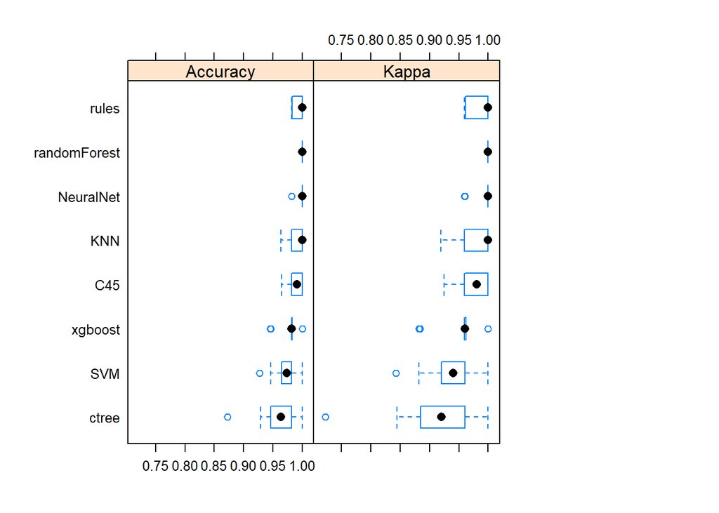

```r
library(lattice)
bwplot(resamps, layout = c(3, 1))
```

```r
difs <- diff(resamps)
difs
```

```
##
## Call:
## diff.resamples(x = resamps)
##
## Models: ctree, C45, SVM, KNN, rules, randomForest, xgboost, NeuralNet
## Metrics: Accuracy, Kappa
## Number of differences: 28
## p-value adjustment: bonferroni
```

```r
summary(difs)
```

```
##
## Call:
## summary.diff.resamples(object = difs)
##
## p-value adjustment: bonferroni
## Upper diagonal: estimates of the difference
## Lower diagonal: p-value for H0: difference = 0
##
## Accuracy
##              ctree   C45       SVM       KNN       rules     randomForest
## ctree                -0.032340 -0.012599 -0.034031 -0.037666 -0.043057
## C45          0.53129            0.019741 -0.001691 -0.005326 -0.010717
## SVM          1.00000 0.67133             -0.021432 -0.025067 -0.030458
## KNN          0.20097 1.00000   0.24159             -0.003635 -0.009026
## rules        0.14435 1.00000   0.07586   1.00000             -0.005391
## randomForest 0.13041 0.64481   0.03633   1.00000   1.00000
## xgboost      0.70024 1.00000   1.00000   1.00000   0.23830   0.05556
## NeuralNet    0.14093 1.00000   0.02506   1.00000   1.00000   1.00000
##              xgboost   NeuralNet
## ctree        -0.019743 -0.039453
## C45           0.012597 -0.007113
## SVM          -0.007144 -0.026854
## KNN           0.014288 -0.005422
## rules         0.017923 -0.001787
## randomForest  0.023314  0.003604
## xgboost                -0.019710
## NeuralNet    0.09155
##
## Kappa
##              ctree   C45       SVM       KNN       rules     randomForest
## ctree                -0.070574 -0.027112 -0.074034 -0.082175 -0.094113
## C45          0.51902            0.043462 -0.003460 -0.011601 -0.023539
## SVM          1.00000 0.63732             -0.046922 -0.055063 -0.067001
## KNN          0.20297 1.00000   0.25402             -0.008141 -0.020079
## rules        0.13903 1.00000   0.06821   1.00000             -0.011938
## randomForest 0.12734 0.61723   0.03299   1.00000   1.00000
## xgboost      0.73116 1.00000   0.98830   1.00000   0.23670   0.05183
## NeuralNet    0.13950 1.00000   0.02329   1.00000   1.00000   1.00000
##              xgboost   NeuralNet
## ctree        -0.043217 -0.086108
## C45           0.027357 -0.015533
## SVM          -0.016105 -0.058996
## KNN           0.030817 -0.012073
## rules         0.038958 -0.003933
## randomForest  0.050896  0.008006
## xgboost                -0.042891
## NeuralNet    0.09218
```

**Prediccion y matriz de confusion**

```r
dt_pred <- predict(ctreeFit, cancer_test)
dt_pred
```

```
##   [1] 2 4 2 2 4 2 2 4 4 2 4 2 4 2 4 2 2 2 2 2 4 2 4 4 2 4 4 2 2 2 4 4 2 2 4 2 4
##  [38] 4 2 2 2 2 2 2 4 4 4 2 2 2 2 4 4 2 2 4 2 4 2 2 4 2 2 4 4 4 4 4 4 4 4 4 2 4
##  [75] 2 2 2 2 2 4 2 2 4 2 2 2 4 2 2 2 2 4 2 2 4 4 4 2 2 4 2 2 2 2 2 2 2 2 2 2 4
## [112] 4 2 2 2 4 2 2 4 4 2 2 2 2 2 4 2 2 2 2 2 2 2 2 4 2 2 2 4
## Levels: 2 4
```

*Matriz de confusion*

```r
confusionMatrix(dt_pred,factor(cancer_test$Clases))
```

```
## Confusion Matrix and Statistics
##
##           Reference
## Prediction  2  4
##          2 87  1
##          4  4 47
##
##                Accuracy : 0.964
##                  95% CI : (0.9181, 0.9882)
##     No Information Rate : 0.6547
##     P-Value [Acc > NIR] : <2e-16
##
##                   Kappa : 0.9216
##
##  Mcnemar's Test P-Value : 0.3711
##
##             Sensitivity : 0.9560
##             Specificity : 0.9792
##          Pos Pred Value : 0.9886
##          Neg Pred Value : 0.9216
##              Prevalence : 0.6547
##          Detection Rate : 0.6259
##    Detection Prevalence : 0.6331
##       Balanced Accuracy : 0.9676
##
##        'Positive' Class : 2
##
```

```r
# https://rpubs.com/chzelada/275494
```

*Random forest*

```r
rf_pred <- predict(randomForestFit, cancer_test)
rf_pred
```

```
##   [1] 2 4 2 2 4 2 2 4 4 2 4 4 4 2 4 2 2 2 2 2 4 2 4 4 2 4 4 2 2 2 4 4 2 2 4 2 4
##  [38] 4 2 2 2 2 2 2 4 4 4 2 2 2 2 4 4 2 2 4 2 4 2 2 4 2 2 4 4 4 4 4 4 4 4 4 2 4
##  [75] 2 2 2 2 2 4 2 2 4 2 2 2 4 2 2 2 2 4 2 2 4 4 4 2 2 4 2 2 2 2 2 2 2 2 2 2 4
## [112] 4 2 2 2 4 2 2 4 4 2 2 2 2 2 4 2 2 2 2 2 2 2 2 4 2 2 2 4
## Levels: 2 4
```

*Matriz de confusion*

```r
confusionMatrix(rf_pred,factor(cancer_test$Clases))
```

```
## Confusion Matrix and Statistics
##
##           Reference
## Prediction  2  4
##          2 87  0
##          4  4 48
##
##                Accuracy : 0.9712
##                  95% CI : (0.928, 0.9921)
##     No Information Rate : 0.6547
##     P-Value [Acc > NIR] : <2e-16
##
##                   Kappa : 0.9376
##
##  Mcnemar's Test P-Value : 0.1336
##
##             Sensitivity : 0.9560
##             Specificity : 1.0000
##          Pos Pred Value : 1.0000
##          Neg Pred Value : 0.9231
##              Prevalence : 0.6547
##          Detection Rate : 0.6259
##    Detection Prevalence : 0.6259
##       Balanced Accuracy : 0.9780
##
##        'Positive' Class : 2
##
```

```r
# https://rpubs.com/chzelada/275494
```

```r
#https://www.positioniseverything.net/error-data-and-reference-should-be-factors-with-the-same-levels/
```

**CREANDO MODELOS CON OTRAS LIBRERIAS Y GRAFICANDO RESULTADOS**

```r
library(tidyverse)
library(ggplot2)
library(caret)

decisionplot <- function(model, data, class_var,
  predict_type = c("class", "prob"), resolution = 5 * 75) {

      # resolution is set to 75 dpi if the image is rendered 5 inces wide.
      y <- data %>% pull(class_var)
      x <- data %>% dplyr::select(-all_of(class_var))

      # resubstitution accuracy
      prediction <- predict(model, x, type = predict_type[1])

      # LDA returns a list
      if(is.list(prediction)) prediction <- prediction$class
      prediction <- factor(prediction, levels = levels(y))
      cm <- confusionMatrix(data = prediction, reference = y)
      acc <- cm$overall["Accuracy"]

      # evaluate model on a grid
      r <- sapply(x[, 1:2], range, na.rm = TRUE)
      xs <- seq(r[1,1], r[2,1], length.out = resolution)
      ys <- seq(r[1,2], r[2,2], length.out = resolution)
      g <- cbind(rep(xs, each = resolution), rep(ys, time = resolution))
      colnames(g) <- colnames(r)
      g <- as_tibble(g)

      ### guess how to get class labels from predict
      ### (unfortunately not very consistent between models)
      cl <- predict(model, g, type = predict_type[1])

      # LDA returns a list
      if(is.list(cl)) {
      prob <- cl$posterior
      cl <- cl$class
      } else
      try(prob <- predict(model, g, type = predict_type[2]))

      # we visualize the difference in probability/score between the
      # winning class and the second best class.
      # don't use probability if predict for the classifier does not support it.
      max_prob <- 1
      try({
      max_prob <- t(apply(prob, MARGIN = 1, sort, decreasing = TRUE))
      max_prob <- max_prob[,1] - max_prob[,2]
      }, silent = TRUE)
      cl <- factor(cl, levels = levels(y))
      g <- g %>% add_column(prediction = cl, probability = max_prob)
      ggplot(g, mapping = aes_string(
      x = colnames(g)[1],
      y = colnames(g)[2])) +
        geom_raster(mapping = aes(fill = prediction, alpha = probability)) +
      geom_contour(mapping = aes(z = as.numeric(prediction)),
      bins = length(levels(cl)), size = .5, color = "black") +
      geom_point(data = data, mapping = aes_string(
      x = colnames(data)[1],
      y = colnames(data)[2],
      shape = class_var), alpha = .7) +
      scale_alpha_continuous(range = c(0,1), limits = c(0,1), guide = "none") +
      labs(subtitle = paste("Training accuracy:", round(acc, 2)))
  }
```

```r
dataset_cancer <- as_tibble(dataset_cancer)
x <- dataset_cancer %>% dplyr::select(Espesor_grupo_celulas, Uniformiformidad_tamanio_celular, Clases)
x$Clases<- as.factor(x$Clases)
```

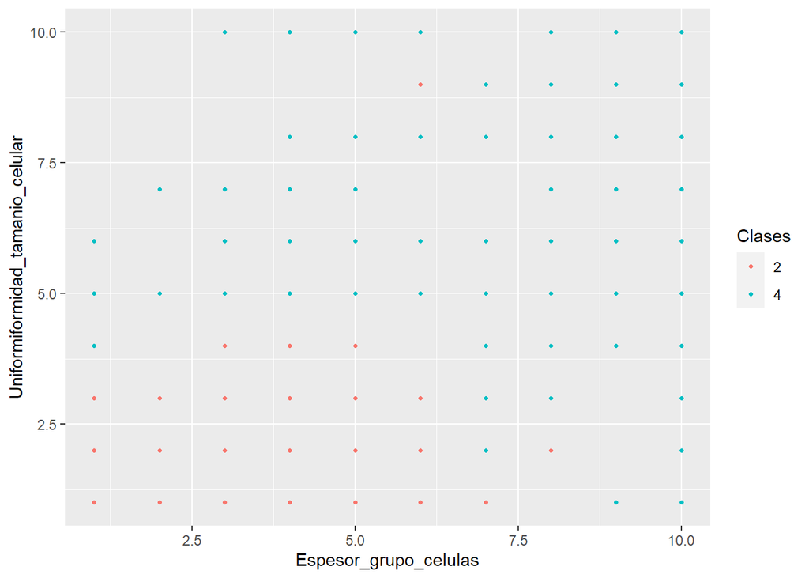

```r
ggplot() + geom_point(data = dataset_cancer, aes(Espesor_grupo_celulas, Uniformiformidad_tamanio_celular, color = Clases), size = 0.9)
```

*Clasificador K-Nearest Neighbors*

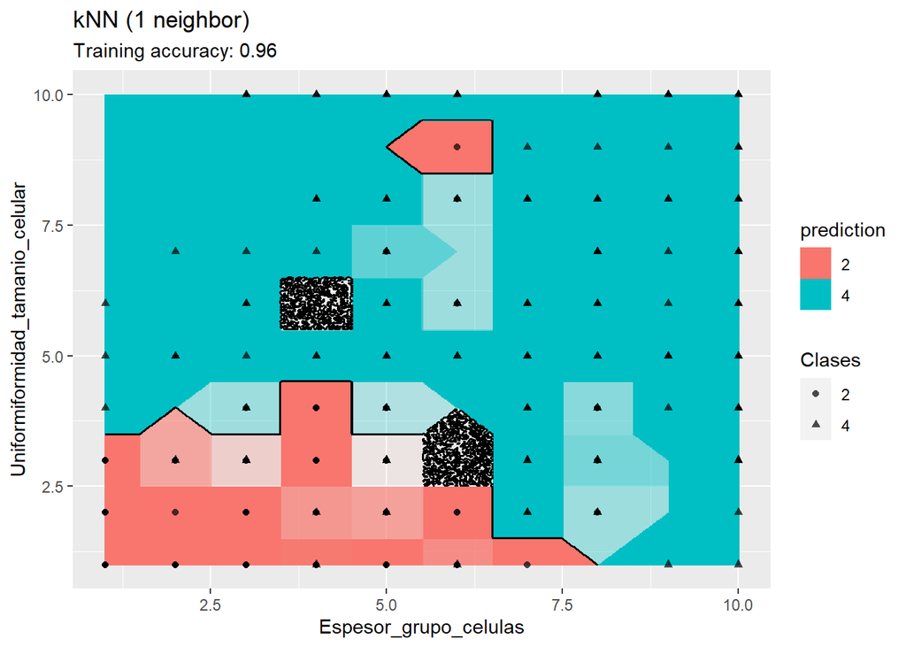

```r
library(caret)
model <- x %>% knn3(Clases ~ ., data = ., k = 1)
decisionplot(model, x, class_var = "Clases") + labs(title = "kNN (1 neighbor)")
```